# StreamingAnomalyDetectionNotebook

### Christina Karalka | AEM: 145 | e-mail: kchristi@csd.auth.gr

### README

This notebook contains code for training and evaluating the proposed anomaly detection models, as well as results analysis and plots. It is organised into 4 sections:

1. **Selected Time Series per Dataset**  
   Defines the file paths of the selected single normality time series.
2. **Methodology: Model Definitions**  
   Consists of functions that can be used to apply each model to a given time series.
3. **Run Experiments**  
   Contains the code for running the experiments of this project. All experiments listed were previously executed and the results were saved to dedicated json files that can be found in the OUTPUTS directory. Therefore, executing this part of the notebook is not neccessary for previewing the outputs/results.
4. **Experimental Results**  
   Presents the results of the experiments by reading the stored json files. It contains tables of performance measurements and various plots, organized per experiment type. At the current state of this notebook all the cells of this section have been executed, to provide easy access to the recorded results. In any case, this section can be executed independently from the computationally heavy Section 3.

An HTML file of this notebook can be found in the same directory.

````python
import warnings
warnings.filterwarnings('ignore')

import re
import json
import random
import os, sys
from os import path, makedirs
from pathlib import Path
from typing import List, Union, Tuple
from itertools import permutations, combinations

import time
import math
import glob
import numpy as np
import pandas as pd
import matplotlib.pyplot as plt
%matplotlib inline

sys.path.append(os.getcwd())
sys.path.append(path.join(os.getcwd(), "TSB_UAD"))

from TSB_UAD.models.distance import Fourier
from TSB_UAD.models.feature import Window
# ! add ```plt.show()``` to utils/slidingWindow.py/plotFig to display plots
from TSB_UAD.utils.slidingWindows import find_length,plotFig, printResult
from sklearn.preprocessing import MinMaxScaler

from TSB_UAD.models.sand import SAND
````

```python
sys.path.append(path.join(os.getcwd(), "EncDec-AD"))
from enc_dec_ad import EncDecAD

from collections import deque

from sklearn.metrics import classification_report
from sklearn.metrics import accuracy_score
from sklearn.metrics import roc_auc_score, average_precision_score, fbeta_score
from sklearn.metrics import confusion_matrix

from scipy.stats import ks_2samp
from tqdm import tqdm
```

```python
# Setup GPU

os.environ["CUDA_DEVICE_ORDER"] = "PCI_BUS_ID"
os.environ["CUDA_VISIBLE_DEVICES"] = "0"

import torch
from torch.cuda import current_device, is_available
device = current_device() if is_available() else None
print(is_available(), device)

import tensorflow as tf
print(tf.config.list_physical_devices('GPU'))  # list shouldn't be empty in case GPU is available

tf.random.set_seed(42)
random.seed(42)
np.random.seed(42)
torch.manual_seed(42)
torch.cuda.manual_seed(42)
torch.cuda.manual_seed_all(42)
torch.backends.cudnn.benchmark = False
torch.backends.cudnn.deterministic = True
```

```
True 0
[PhysicalDevice(name='/physical_device:GPU:0', device_type='GPU')]
```

```python
# load AE-LSTM model
sys.path.append(path.join(os.getcwd(), "redsofa_online_ae_lstm"))
from source.AELSTMOnline import AELSTMOnline
from source.baseAnomalyDetector import *
from tensorflow.keras import backend as K
from tensorflow.keras.models import Sequential
from tensorflow.keras.layers import Dense, LSTM, Dropout, TimeDistributed, RepeatVector
from skmultiflow.data import FileStream
```

```
Number of GPUs Available:  1
```

```python
# functions for loading datasets, handling results and making plots
sys.path.append(path.join(os.getcwd(), "utils"))
from utils.handle_datasets import *
from utils.handle_results_files import *
from utils.make_plots import *

pd.set_option('display.max_rows', None)
pd.set_option('display.max_columns', None)
pd.set_option('display.width', 5000)
```

# 1. Selected Time Series per Dataset

16 public datasets, from which one series was randomly selected, with a preference for samples of larger lengths. These series will be used for normality 1 experiments. Additionally, pairs and triplets will be concatenated for normality levels 2 and 3 respectively (readers are referred to the respective experimentation sections). Characteristics for each of the selected series are presented in the results section of this notebook.

```python
DODGERS = 'Dodgers/101-freeway-traffic.test.out'
ECG = 'ECG/MBA_ECG803_data.out'
IOPS = 'IOPS/KPI-1c6d7a26-1f1a-3321-bb4d-7a9d969ec8f0.test.out'
KDD21 = 'KDD21/001_UCR_Anomaly_DISTORTED1sddb40_35000_52000_52620.out'
MGAB = 'MGAB/1.test.out'
NAB = 'NAB/NAB_data_Traffic_1.out'
SENSORSCOPE = 'SensorScope/stb-2.test.out'
YAHOO = 'YAHOO/Yahoo_A1real_1_data.out'
DAPHNET = 'Daphnet/S01R02E0.test.csv@1.out'
GHL = 'GHL/01_Lev_fault_Temp_corr_seed_11_vars_23.test.csv@4.out'
GENESIS = 'Genesis/genesis-anomalies.test.csv@1.out'
MITDB = 'MITDB/100.test.csv@1.out'
OPPORTUNITY = 'OPPORTUNITY/S1-ADL1.test.csv@16.out'
OCCUPANCY = 'Occupancy/room-occupancy.train.csv@3.out'
SMD = 'SMD/machine-1-1.test.csv@1.out'
SVDB = 'SVDB/801.test.csv@1.out'

ALL_SETS = [DODGERS, ECG, IOPS, KDD21, MGAB, NAB, SENSORSCOPE, YAHOO, DAPHNET, GHL, GENESIS, MITDB, OPPORTUNITY,
            OCCUPANCY, SMD, SVDB]
```

```
Series len = 78479
Normality = 2
Distro shift indexes = [50000]
```

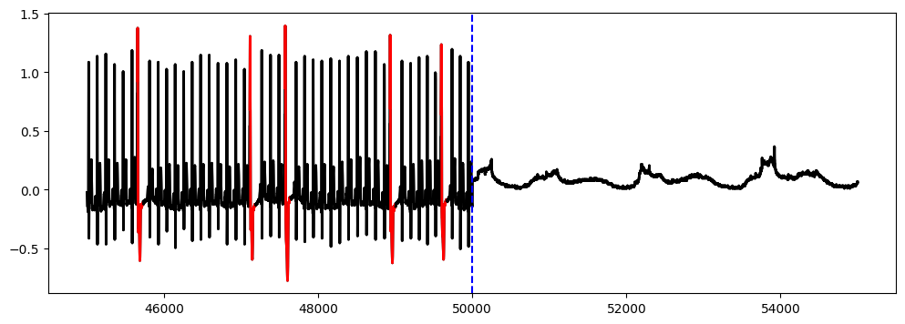

```python
# How to load a dataset. For normality>1, add multiple time series files to the filenames list

filenames = [ECG, SMD]
df, normality, shift_idxs = load_dataset(filenames, sample_size=50000)
```

# 2. Methodology: Model Definitions

This section includes the setup of the proposed models and baselines:

- SAND: A distance/cluster-based algorithm for streaming anomaly detection (AD).
- EncDec-AD: An LSTM-based autoencoder model proposed for offline AD.
- EncDec-AD-Batch: A naive streaming variation of EncDec-AD that operates independently in each data batch.
- OnlineEncDec-AD: A streaming variation of EncDec-AD incorporating incremental learning and concept drift detection mechanisms.
- AE-LSTM: An additional LSTM-based autoencoder baseline following a similar setup with the proposed OnlineEncDec-AD model.

The code for SAND, EncDec-AD and AE-LSTM models can be found on dedicated directories in the base directory of this project. The training and evaluation setup of the two streaming variants of EncDec-AD can be found in this notebook in dedicated subsections.

## 2.1. SAND method

### [Q5] Streaming baseline AD method

````python
def SAND_model(df: pd.DataFrame, filenames: List[str], normality: int):

    name = "_".join(filenames)
    modelName='SAND'
    start_time = time.time()

    # process data
    data = df[0]
    label = df[1]
    slidingWindow = find_length(data)

    print("Estimated Subsequence length: ",slidingWindow)
    print("Time series length: ",len(data))
    print("Number of abnormal points: ",list(label).count(1))

    # train model
    clf = SAND(pattern_length = slidingWindow, subsequence_length = 4*(slidingWindow))
    x = data
    clf.fit(x, online=True, alpha=0.5, init_length=5000, batch_size=5000, verbose=True, overlaping_rate=int(4*slidingWindow))

    # test
    score = clf.decision_scores_
    score = MinMaxScaler(feature_range=(0,1)).fit_transform(score.reshape(-1,1)).ravel()
    elapsed_time = time.time() - start_time
    # ! add ```plt.show()``` to utils/slidingWindow.py/plotFig to display plots
    plotFig(data, label, score, slidingWindow, fileName=name, modelName=modelName)

    # save results
    return gather_TSB_results(modelName, True, label, score, slidingWindow, filenames, normality, elapsed_time)
````

```python
# SAND_model(df, filenames, normality)
```

## 2.2. EncDec-AD

### [Q4] Offline/Non-streaming baseline method

LSTM Encoder/Decoder methodology - DeepADoTS implementation

```python
def separate_sets(X, Y, train_perc=0.1, val_perc=0.0, first_shift_idx: int = None):

    train_idx = int(train_perc * len(X)) if first_shift_idx is None else int(train_perc * first_shift_idx)
    X_train, Y_train = X[:train_idx].reset_index(drop=True), Y[:train_idx].reset_index(drop=True)

    if val_perc > 0.0:
        val_idx = int(val_perc * len(X))
        X_val, Y_val = X[train_idx:train_idx + val_idx].reset_index(drop=True), \
                       Y[train_idx:train_idx + val_idx].reset_index(drop=True)
    else:
        X_val, Y_val = None, None

    test_idx = train_idx + (val_idx if val_perc > 0.0 else 0)
    X_test, Y_test = X[test_idx:].reset_index(drop=True), Y[test_idx:].reset_index(drop=True)

    return X_train, Y_train, X_val, Y_val, X_test, Y_test
```

```python
def EncDecAD_model(df: pd.DataFrame, filenames: List[str], normality: int, shift_idx: List[int]=None, online_mode=False):
    name = "_".join(filenames)
    modelName = "EncDec-AD"
    start_time = time.time()

    # prepare dataset
    X = df[[0]]
    Y = df[1]
    n_features = X.shape[1]
    slidingWindow = find_length(X[0])
    first_shift_idx = None if normality==1 or shift_idx is None else shift_idx[0]
    X_train, Y_train, X_val, Y_val, X_test, Y_test = separate_sets(X, Y, train_perc=0.2, val_perc=0, first_shift_idx=first_shift_idx)
    slidingWindow = min(slidingWindow, X_train.shape[0])
    print('sliding window = ', slidingWindow)

    # train
    p = len(str(slidingWindow)) - 1
    p = pow(10, p)
    batch_size = min(int(4 * (slidingWindow // p) * p), X_train.shape[0])
    model = EncDecAD(n_features = n_features,
                     hidden_size = 32,
                     sequence_length = slidingWindow,
                     gpu = device)
    model.fit(X_train, num_epochs=40, batch_size=batch_size)

    # test
    score, loss = model.predict(X_test, batch_size=batch_size)
    elapsed_time = time.time() - start_time

    if online_mode:
        return score, X_test, Y_test
    else:
        # show evaluation results
        score = MinMaxScaler(feature_range=(0,1)).fit_transform(score.reshape(-1,1)).ravel()
        plotFig(X_test[0], Y_test, score, slidingWindow, fileName=name, modelName=modelName)
        return gather_TSB_results(modelName, online_mode, Y_test, score, slidingWindow, filenames, normality, elapsed_time)
```

```python
# EncDecAD_model(df, filenames, normality, shift_idxs, online_mode=False)
```

## 2.3. EncDec-AD-Batch

### [Q6] Naive streaming variant (1): Offline method is applied to each batch of the data that arrives. No modification of the method itself.

Offline method: LSTM Encoder/Decoder - DeepADoTS implementation

```python
def create_stream(df: pd.DataFrame, stream_batch_size: int = 10000) -> List[pd.DataFrame]:
    # first stream batch boundaries
    start = 0
    end = min(stream_batch_size, df.shape[0])

    stream = []
    while start <df.shape[0] and end <= df.shape[0]:
        stream_batch = df.iloc[start:end].reset_index(drop=True)
        stream.append(stream_batch)

        # move on to the next batch of the stream
        start += stream_batch_size
        end += stream_batch_size
        end = min(end, df.shape[0])

    # in case the last batch is smaller than the seq len, concat it with the previous batch
    sequence_len = find_length(stream[0][0])
    if stream[-1].shape[0] < sequence_len:
        stream[-2] = pd.concat([stream[-2], stream[-1]], ignore_index=True)
        stream = stream[:-1]
    return stream
```

```python
def EncDecAD_Batch_model(df: pd.DataFrame, filenames: List[str], normality:int, stream_batch_size:int=10000):
    modelName = "EncDec-AD-Batch"
    stream = create_stream(df, stream_batch_size)
    start_time = time.time()

    # for gathering stream results
    score = np.empty(0)
    X_test = pd.DataFrame(columns=[0])
    Y_test = pd.Series(dtype=df[1].dtype)

    for i, batch in enumerate(stream):
        print(f"Batch {i+1}/{len(stream)} with # {batch.shape[0]} points")
        # apply non-streaming method on each batch independently
        batch_score, batch_X_test, batch_Y_test = EncDecAD_model(batch, filenames, normality, online_mode=True)

        # append batch results
        score = np.concatenate((score, batch_score), axis=0)
        X_test = pd.concat([X_test, batch_X_test], ignore_index=True)  # needed for plotFig func
        Y_test = pd.concat([Y_test, batch_Y_test], ignore_index=True)  # points used for training are excluded from testing

        # move on to the next branch

    # show evaluation results on the whole stream
    elapsed_time = time.time() - start_time
    sliding_window = find_length(df[0])
    score = MinMaxScaler(feature_range=(0,1)).fit_transform(score.reshape(-1,1)).ravel()
    plotFig(X_test[0], Y_test, score, sliding_window, fileName="_".join(filenames), modelName=modelName)
    return gather_TSB_results(modelName, True, Y_test, score, sliding_window, filenames, normality, elapsed_time)
```

```python
# EncDecAD_Batch_model(df, filenames, normality, batch_size=int(df.shape[0] / 10))
```

## 2.4. EncDec-AD-Online

### [Q6] Streaming variant 2: Streaming Anomaly Detection with Incremental Learning and Concept Drift Detection

In the realm of time series anomaly detection, adapting to continuously arriving data points in a streaming setting is crucial for timely and accurate detection of anomalies. We propose an online adaptation of the EncDec-AD model, originally designed for offline detection using an LSTM autoencoder architecture. In our approach, the model is initially trained on a specified percentage of the initial data stream to establish a baseline. Subsequently, it undergoes incremental learning, updating its parameters in real-time as new data arrives. To address concept drift, which can significantly affect model performance, we integrate a Kolmogorov-Smirnov (KS) test to monitor reconstruction errors. This test detects significant changes in the error distribution, triggering a complete retraining of the model when necessary. Additionally, the anomaly score threshold is dynamic and determined by the theta-percentile, calculated with linear interpolation. This combination of initial training, incremental learning, and concept drift detection ensures that the EncDec-AD model remains accurate and responsive to changes in the data stream, making it well-suited for real-time anomaly detection in dynamic environments. This model was inspired by the AE-LSTM and strAEm++DD models. Summary:

- The EncDec-AD model (an LSTM Autoencoder) is initially trained using a percentage (train_perc) of the initial points in the data stream.
- It is subsequently updated through incremental learning.
- A concept drift detection mechanism monitors the model's predictions (reconstruction errors) and triggers the model to be retrained from scratch when significant changes are detected.
- Dynamic annomaly score threshold determined by the theta-precentile.

```python
class CapacityQueue:
    def __init__(self, queue_capacity, with_replacement=False):
        self.replaced_elements = None
        self.total_elements = None
        self.queue = None

        self.queue_capacity = queue_capacity  # Maximum capacity of the queue
        self.with_replacement = with_replacement
        self.reset()

    def __len__(self):
        return len(self.queue)

    def reset(self):
        self.queue = deque(maxlen=self.queue_capacity if self.with_replacement else None)  # Initialize deque with a fixed size
        self.total_elements = 0  # Total elements added
        self.replaced_elements = 0  # Number of elements replaced

    def push(self, x):
        if self.with_replacement and len(self.queue) == self.queue_capacity:
            # If the queue is full, increment replaced_elements
            self.replaced_elements += 1
        self.queue.append(x)
        self.total_elements += 1

    def isFull(self):
        return len(self.queue) >= self.queue_capacity

    def percentage_replaced(self):
        if self.total_elements < self.queue_capacity:
            return 0  # No replacement has occurred if the total elements added is less than capacity
        return (self.replaced_elements / self.total_elements) * 100

    def copy_from(self, other):
        self.queue = deque(other.queue, maxlen=other.queue_capacity)
        self.total_elements = other.total_elements
        self.replaced_elements = other.replaced_elements

# ======================================================================================================

class OnlineAD:

    def __init__(self,
                 df: pd.DataFrame,
                 filenames: List[str],
                 normality: int,
                 shift_idx: List[int] = None,
                 Wincrem: int = 1000, Wdrift: int = 200,
                 max_buffer_len: int = 2000,
                 incremental_cutoff: int = 50,
                 percentile_cutoff: int = 92,
                 ks_significance_level: float = 0.001,
                 training_epochs: int = 40,
                 incremental_training_epochs: int = 10,
                 use_increm_learning: bool = True,
                 use_concept_drift: bool = True,
                 use_dynamic_thrs: bool = True,
                 verbose: int = 0
                 ):
        self.name = "OnlineEncDecAD"
        self.v = verbose
        self.training_epochs = training_epochs
        self.incremental_training_epochs = incremental_training_epochs
        self.max_buffer_len = max_buffer_len

        self.use_increm_learning = use_increm_learning
        self.use_concept_drift = use_concept_drift
        self.use_dynamic_thrs = use_dynamic_thrs

        self.Wincrem = Wincrem
        self.Wdrift = Wdrift
        self.incremental_cutoff = incremental_cutoff
        self.percentile_cutoff = percentile_cutoff
        self.ks_significance_level = ks_significance_level

        self.X, self.Y = None, None
        self.sequence_length = None
        self.n_features = None
        self.model = None
        self.theta_t = None
        self.drift_idxs = []
        self.increm_idxs = []
        self.initialize(df, shift_idx)

        self.errors = []
        self.Y_hat = []
        self.pred_buffer= CapacityQueue(self.max_buffer_len)
        self.wnd_increm = CapacityQueue(self.Wincrem, True)
        self.wnd_drift  = CapacityQueue(self.Wdrift)
        self.wnd_ref    = CapacityQueue(self.Wdrift)

        start_time = time.time()
        self.parse_stream()
        self.get_predictions()
        self.elapsed_time = time.time() - start_time
        self.extract_results(filenames, normality)

    # -----------------------------------------------------------------------------------------------

    def initialize(self, df: pd.DataFrame, shift_idx: List[int]):
        X = df[[0]]
        Y = df[1]
        self.n_features = X.shape[1]

        # drift windows (Wdrift size) should be at least as large as the sequence
        self.sequence_length = find_length(X[0])
        if self.sequence_length > self.Wdrift:
            self.Wdrift = int(self.sequence_length)

        first_shift_idx = None if shift_idx is None or len(shift_idx)==0 else shift_idx[0]
        X_init_train, Y_init_train, _, _, self.X, self.Y = separate_sets(X, Y, train_perc=0.2, val_perc=0, first_shift_idx=first_shift_idx)
        print(f"Seq len = {self.sequence_length}\nInitializing model with {X_init_train.shape[0]} samples...")
        self.fit_model(X_init_train, True, 0)


    def fit_model(self, X: Union[pd.DataFrame, CapacityQueue], reset_model: bool, t:int):

        if reset_model:
            self.model = EncDecAD(
                n_features = self.n_features,
                hidden_size = 32,
                sequence_length = self.sequence_length,
                gpu = device)
            epochs = self.training_epochs
        else:
            epochs = self.incremental_training_epochs

        X = self.toDF(X)

        if self.v>=1: print(f"\nTraining model ({'from scratch' if reset_model else 'incremental'}) with {X.shape} samples")
        if reset_model: self.drift_idxs.append(t)
        else: self.increm_idxs.append(t)

        self.model.fit(X, epochs, batch_size = self.get_batch_size(X), show_progress_bar=(self.v>=2 or t==0))

        if t==0 or self.use_dynamic_thrs:
            _, train_loss = self.model.predict(X)
            self.theta_t  = self.calc_percentile(train_loss)
            if self.v>=1: print(f"New theta_t = {self.theta_t}\n{'-'*30}")


    def calc_percentile(self, loss):
        return np.percentile(loss, self.percentile_cutoff, interpolation='linear')



    def predict_model(self, X: Union[pd.DataFrame, CapacityQueue], is_output: bool):
        X = self.toDF(X)

        _, loss = self.model.predict(X, batch_size = self.get_batch_size(X))
        Y_hat = (loss > self.theta_t).astype(int)

        if is_output:
            self.errors.append(loss)
            self.Y_hat.append(Y_hat)

        return loss
```

```python
    # -------------------------------------------------------------------------------------------------
    def parse_stream(self):

        print(f"Parse stream with #{self.X.shape[0]} data points...")
        for (t, xt) in self.X.iterrows():
            if self.v==0 and t%5000==0: print(f"{t} ->", end='')

            self.pred_buffer.push(xt)

            if self.pred_buffer.isFull():
                if self.v>=2: print(f"Predict buffer (# {len(self.pred_buffer)}) since full")
                self.predict_model(self.pred_buffer, True)
                self.pred_buffer.reset()

            if self.X.shape[0] - t > self.sequence_length:  # at least one sequence should remain in the stream
                if self.use_increm_learning:
                    self.incremental_training(t, xt)
                if self.use_concept_drift:
                    self.concept_drift_detection(t, xt)

        if len(self.pred_buffer) > 0:
            print(f"\nPredict last buffer (# {len(self.pred_buffer)}) before finish")
            self.predict_model(self.pred_buffer, True)
            self.pred_buffer.reset()



    def incremental_training(self, t, xt):
        self.wnd_increm.push(xt)
        if self.wnd_increm.isFull() or self.wnd_increm.percentage_replaced() >= self.incremental_cutoff:

            if self.v>=2: print(f"Incremental training (# {len(self.wnd_increm)}) at t = {t}"); self.printObjects()

            self.fit_model(self.wnd_increm, False, t)
            self.wnd_increm.reset()



    def concept_drift_detection(self, t, xt):
        if not self.wnd_ref.isFull():
            self.wnd_ref.push(xt)
        elif not self.wnd_drift.isFull():
            self.wnd_drift.push(xt)
        else:
            ref_loss = self.predict_model(self.wnd_ref, False)
            drift_loss = self.predict_model(self.wnd_drift, False)
            drift_detected = self.check_for_drift(ref_loss, drift_loss, t)

            if drift_detected:
                if self.v>=2:
                    print(f"Drift detected at t = {t}")
                    self.printObjects()

                if len(self.pred_buffer) > self.sequence_length:
                    if self.v>=2: print(f"Predict buffer (# {len(self.pred_buffer)})  before drift reset step")
                    self.predict_model(self.pred_buffer, True)
                    self.pred_buffer.reset()

                self.fit_model(self.wnd_drift, True, t)
                self.wnd_ref.reset()
                self.wnd_drift.reset()
                self.wnd_increm.reset()
            else:
                self.wnd_ref.copy_from(self.wnd_drift)
                self.wnd_drift.reset()
                if self.v>=2:
                    print(f"No Drift at t = {t}"); self.printObjects()



    def check_for_drift(self, ref_loss: np.ndarray, drift_loss: np.ndarray, t:int):
        """:return:
            True:  The two distributions are significantly different (reject H0).
            False: The two distributions are not significantly different (fail to reject H0).
        """""
        ks_statistic, p_value = ks_2samp(ref_loss.ravel(), drift_loss.ravel())
        if self.v>=2: print(f"Checked for drift p-value = {p_value} at t = {t}")
        return p_value < self.ks_significance_level


    # -------------------------------------------------------------------------------------------------

    def toDF(self, X):
        if isinstance(X, pd.DataFrame):
            return X
        elif isinstance(X, CapacityQueue):
            return pd.DataFrame(X.queue)
        else:
            ValueError(f"Invalid x type: {type(X)}")


    def get_batch_size(self, X):
        data_len = X.shape[0] if isinstance(X, pd.DataFrame) else len(X)
        p = len(str(self.sequence_length)) - 1
        p = pow(10, p)
        batch_size = min(int(4 * (self.sequence_length // p) * p), data_len)
        return batch_size

    def get_predictions(self):
        self.errors = np.concatenate(self.errors, axis=1).ravel()
        self.Y_hat  = np.concatenate(self.Y_hat, axis=1).ravel()


    def results(self):

        target_names = ['normal', 'anamoly']
        print("Accuarcy: " + str(accuracy_score(self.Y, self.Y_hat)))
        print("AUC: " + str(roc_auc_score(self.Y, self.Y_hat)))
        print("AUC PR: " + str(average_precision_score(self.Y, self.Y_hat)))
        print(confusion_matrix(self.Y, self.Y_hat))
        print(classification_report(self.Y, self.Y_hat, target_names=target_names, digits=4))

        return {'name': self.name,
                'Accuarcy': str(accuracy_score(self.Y, self.Y_hat)),
                'AUC': str(roc_auc_score(self.Y, self.Y_hat)),
                'AUC PR': str(average_precision_score(self.Y, self.Y_hat)),
                'confusion matrix': confusion_matrix(self.Y, self.Y_hat),
                'report': (classification_report(self.Y, self.Y_hat, target_names=target_names, digits=4, output_dict=True))}


    def extract_results(self, filenames, normality):
        results = self.results()
        ablation_study = not self.use_increm_learning or not self.use_concept_drift or not self.use_dynamic_thrs
        additional_stats = {
            "ablation": ablation_study,
            "use_increm_learn": self.use_increm_learning,
            "use_drift_detect": self.use_concept_drift,
            "use_dynamic_thrs": self.use_dynamic_thrs,
            "increm_idxs": self.increm_idxs,
            "drift_idxs": self.drift_idxs,
            "ks_significance": self.ks_significance_level,
            "percentile": self.percentile_cutoff
        }
        print(additional_stats)
        results = gather_AELSTM_results(self.name, self.X.shape[0],
                              filenames, normality, results,
                              self.Y, self.Y_hat, self.sequence_length, self.elapsed_time, additional_stats,
                              ablation_study=ablation_study)
        plotFig(self.X[0], self.Y, self.Y_hat.astype(float), self.sequence_length, fileName="_".join(filenames), modelName=self.name)
```

```python
    # -------------------------------------------------------------------------------------------------

    def printObjects(self, message= None):
        print(f"\twnd_ref : # {len(self.wnd_ref)}\t {message}")
        print(f"\twnd_drift : # {len(self.wnd_drift)}")
        print(f"\twnd_incre : # {len(self.wnd_increm)}")
        print(f"\tpred_buff : # {len(self.pred_buffer)}")
```

```python
# model = OnlineAD(df, filenames, normality, shift_idxs, verbose=0)
```

## 2.5. AE-LSTM (Online/Streaming)

### [Q6] Streaming variant 2: Online model sourced from GitHub to serve as an additional baseline

LSTM Autoencoder methodology - redsofa (official) implementation

```python
# helper functions from original repo (OnlineAnomalyDetection.py):

def get_file_stream(data_source, target_column):
    if target_column == None:
        stream = FileStream(data_source, allow_nan=True, n_targets=0)
    else:
        stream = FileStream(data_source, allow_nan=True, n_targets=1, target_idx=target_column)
    return stream


def genericDetectorSteps(_detector, data_source, target_column, max_samples, batch_size):
    """
    This function include the general steps for an algorithm to detect anomaly for streaming data.
    predict_and_update() will be different based on the class type.
    :param _detector: The detected algorithm we are going to use
    :param data_source: The dataset link
    :param batch_size: size of data to send to algorithm to each iteration for anomaly detection
    :param max_samples: maximum number of samples sent
    :param timestamp_column: column name in the data source which represents timestamp
    :param target_column: column name in the data source which represents target column
    :return: detector object
    """
    _detector.stream = get_file_stream(data_source, target_column)
    _detector.start_time = time.time()

    if _detector.isPretrain:
        _detector.pre_train(_detector.isSupervised)
    else:
        # if not pretrain, skip these data
        _detector.get_next_stream(_detector.initial_batch_training_size)

    while _detector.n_samples < max_samples and _detector.stream.has_more_samples():
        # For LSTM, we need to get next sequence instead of data
        X, y = _detector.get_next_sequence(batch_size)
        _detector.predict_and_update(X,y)

    _detector.end_time = time.time()
    return _detector

# run AE-LSTM Online AD model: =======================================================================


def LSTMOnline_model(
    df: pd.DataFrame,
    filenames: List[str],
    normality: int,
    initial_batch_training_size:int,
    neurons:int = 32,
    epochs:int = 30,
    target_column_idx:int = 1
):
    model_name = 'AE-LSTM'
    # save dataframe to a csv (temporarily)
    def prepare_dataset_dataframe() -> str:
        filenames_norm = [filename[:filename.find('/')+1] for filename in filenames]
        filenames_norm = re.sub(r'[^A-Za-z0-9_]',  '.',  "_".join(filenames))
        new_data_source = os.path.join("OUTPUTS", 'temp_dataframes', filenames_norm + "_converted.csv")
        os.makedirs(os.path.dirname(new_data_source), exist_ok=True)
        df.to_csv(new_data_source, index=False)
        return new_data_source

    max_samples = df.shape[0]
    new_data_source = prepare_dataset_dataframe()

    slidingWindow = find_length(df[0])
    p = len(str(slidingWindow)) - 1
    p = pow(10, p)
    batch_size = min(int(4 * (slidingWindow // p) * p), max_samples)

    # define model
    LSTM_model = LSTMOnline(name = model_name,
        detector = AELSTMOnline(time_steps = int(slidingWindow),
                                neurons = neurons,
                                epochs = epochs,
                                anomaly_rate = 30,
                                n_batch = batch_size),
        data_source = new_data_source,
        initial_batch_training_size = initial_batch_training_size,
        batch_size = batch_size,
        max_samples = max_samples,
        timestamp_column = None,
        target_column = target_column_idx,
        isSupervised = False,
        ifSaveResult = True,
        isPretrain = True)

    # training
    start_time = time.time()
    LSTM_model = genericDetectorSteps(
        LSTM_model, new_data_source, target_column_idx, max_samples, batch_size)
    K.clear_session()

    # delete temporary file
    os.remove(new_data_source)

    # make predictions and show results
    results = LSTM_model.results()
    y_pred = np.array(LSTM_model.y_pred)
    label = df[1][initial_batch_training_size:].values
    elapsed_time = time.time() - start_time

    gather_AELSTM_results(model_name, df.shape[0], filenames, normality, results, label, y_pred, slidingWindow, elapsed_time)
    plotFig(df[0], label, y_pred, slidingWindow, fileName=new_data_source, modelName=model_name)

    return LSTM_model, y_pred, results
```

```python
# model, y_pred, results = LSTMOnline_model(df, filenames, normality, initial_batch_training_size=1000)
```

# 3. Run Experiments

This section includes the code for excecuting the experiments of this study. The output of these cells was cleared after saving the results to output json files to reduce the size of this notebook. The results are instead presented in the next section.

```python
import traceback

SAND_ = "SAND"
ENC_DEC_AD_OFFLINE = "EncDec-AD"
ENC_DEC_AD_BATCH = "EncDec-AD-Batch"
ENC_DEC_AD_ONLINE = "OnlineEncDecAD"
AE_LSTM_ONLINE = "AE-LSTM"

def run_model_for_sets(model_name, sets: Union[List[str], List[List[str]]], check_if_results_exist:bool=False,
                       # arguments for OnlineEncDec-AD model (OnlineAD class)
                      onlineAD_use_increment=True, onlineAD_use_concept_drift=True, onlineAD_use_dynam_thrs=True
):
    failed_sets = []
    for i, filename in enumerate(sets):
        try:
            filenames = [filename] if isinstance(filename, str) else filename
            print(f"Set [{i}] = {filenames}")

            sample_size = 100000 if len(filenames)==1 else 50000
            df, normality, shift_idxs = load_dataset(filenames, sample_size=sample_size, plot_series=False)

            if check_if_results_exist:
                results_file = results_file_exists(filenames, normality, model_name, model_name not in [ENC_DEC_AD_OFFLINE])
                if results_file:
                    print(f"Results file already exists {results_file}. Skip", '\n', '-'*50, '\n')
                    continue

            if model_name == SAND_:
                results = SAND_model(df, filenames, normality)

            elif model_name == ENC_DEC_AD_OFFLINE:
                results = EncDecAD_model(df, filenames, normality, shift_idxs, online_mode=False)

            elif model_name == ENC_DEC_AD_BATCH:
                stream_batch_size = int(df.shape[0] / 10)
                results = EncDecAD_Batch_model(df, filenames, normality, stream_batch_size)

            elif model_name == ENC_DEC_AD_ONLINE:
                results = OnlineAD(df, filenames, normality, shift_idxs, verbose=0,
                                   use_increm_learning=onlineAD_use_increment,
                                   use_concept_drift=onlineAD_use_concept_drift,
                                   use_dynamic_thrs=onlineAD_use_dynam_thrs)

            elif model_name == AE_LSTM_ONLINE:
                _,_,results = LSTMOnline_model(df, filenames, normality, initial_batch_training_size=1000)

            print(results, '\n', '-'*50, '\n')
        except Exception as e:
            failed_sets.append(filename)
            print(f"{filename} failed")
            traceback.print_exc()
        # time.sleep(60)

    return failed_sets
```

## 3.1. Normality 1 Experiments

```python
run_model_for_sets(SAND_, ALL_SETS, True)
```

```python
run_model_for_sets(ENC_DEC_AD_OFFLINE, ALL_SETS, True)
```

```python
run_model_for_sets(ENC_DEC_AD_BATCH, ALL_SETS, True)
```

```python
run_model_for_sets(ENC_DEC_AD_ONLINE, ALL_SETS, True)
```

```python
run_model_for_sets(AE_LSTM_ONLINE, ALL_SETS, True)
```

## 3.2. Normality 2 Experiments

- Reject datasets that all or the majority of models showed low performance in normality 1 tests
- Get all combinations (size 2)/possible pairs for the remaining datasets (combinations not permutations)
- Sample at most 50k initial data points from the beginning of each series.
- Training for Offline EncDec-AD and initial training for Online EncDec-AD was performed on the initial 20% of points of the first series in the concatenated series.

```python
norm2sets = ALL_SETS.copy()
for low_perf_norm1_set in [DAPHNET, DODGERS, MITDB,
                           OCCUPANCY, SVDB, KDD21]:
    norm2sets.remove(low_perf_norm1_set)

norm2sets = [list(pair) for pair in list(combinations(norm2sets, 2))]
print(len(norm2sets))
# norm2sets = random.sample(norm2sets, k=10)
# norm2sets
```

```python
run_model_for_sets(SAND_, norm2sets, True)
```

```python
run_model_for_sets(ENC_DEC_AD_OFFLINE, norm2sets, True)
```

```python
run_model_for_sets(ENC_DEC_AD_BATCH, norm2sets, True)
```

```python
run_model_for_sets(ENC_DEC_AD_ONLINE, norm2sets, True)
```

```python
# Due to the high computational cost of AE-LSTM, it is evaluated on a subset of the selected norm 2 series
selected_norm2 = [
    [ECG, MGAB],[ECG, SMD],[ECG, SENSORSCOPE],[GENESIS, OPPORTUNITY],[IOPS, NAB],[IOPS, SMD],
    [MGAB, OPPORTUNITY],[MITDB,OCCUPANCY],[NAB, YAHOO], [OCCUPANCY,SVDB],[SENSORSCOPE,GHL],
    [SENSORSCOPE,SMD], [YAHOO, GENESIS]]
print(len(selected_norm2))
run_model_for_sets(AE_LSTM_ONLINE, selected_norm2, True)
```

## 3.3. Normality 3 Experiments

For triple normality, triplets are generated by combining pairs of normality 2 series that share a common subseries. This ensures that the triplets maintain desired characteristics, such as similar lengths. Each triplet's subseries are then sorted once in ascending and once in descending order of their anomaly ratios (AR), and both resulting normality 3 series are used for experiments.

```python
results_df = prepare_results_df(2, 5, True)
results_df = results_df[results_df['datasets'] != "Average"]
pairs = results_df['datasets_full'].apply(tuple).unique()
triplets = set()

for pair1, pair2 in combinations(pairs, 2):
    if any(elem in pair1 for elem in pair2):
        triplet = tuple(sorted(set(pair1 + pair2)))
        triplets.add(triplet)
triples = [list(triplet) for triplet in triplets]

print("# 3-combinations = ", len(triples))

norm1info = data_info = get_1_normality_info(ALL_SETS, 100000)

def sort_triplet(triplet, reverse):
    sorted_triplet = sorted(triplet, key=lambda x:
                            norm1info[norm1info['datasets'] == x[:x.find('/')]]["anomaly rate"].values[0],
                            reverse=reverse)
    return sorted_triplet

norm3sets = [sort_triplet(triplet, True) for triplet in triplets] + \
            [sort_triplet(triplet, False) for triplet in triplets]

print("# total combinations = ", len(norm3sets))
# for i, triplet in enumerate(norm3sets):
#    names = [s[:s.find('/')] for s in triplet]
#    print(i, names, "->\t", [ norm1info[norm1info["Series"] == s]['anomaly rate'].values[0] for s in names])

# norm3sets
```

```python
run_model_for_sets(SAND_, norm3sets, True)
```

```python
run_model_for_sets(ENC_DEC_AD_OFFLINE, norm3sets, True)
```

```python
run_model_for_sets(ENC_DEC_AD_BATCH, norm3sets, True)
```

```python
run_model_for_sets(ENC_DEC_AD_ONLINE, norm3sets, True)
```

```python
run_model_for_sets(AE_LSTM_ONLINE, norm3sets, True)
```

## 3.4. OnlineEncDec-AD Ablation Study

This section examines the significance of the key mechanisms in the OnlineEncDec-AD model, namely Concept Drift Detection (CDD), Incremental Learning (IL), and Dynamic Anomaly Threshold (DAT). The default model integrates all three mechanisms. To evaluate the individual contributions of each mechanism, we conducted an ablation study by disabling one mechanism at a time and comparing the results. Given the high computational demands of this study, we selected a representative subset of datasets across each level of normality (k=1, 2, and 3) for experimentation.

```python
def run_ablation_study():
    # normality 1
    selected_sets = [
        [MGAB], [ECG], [OPPORTUNITY], [SENSORSCOPE], [DAPHNET], [IOPS], [MITDB], [NAB], [OCCUPANCY], [SMD]
    ]
    # normality 2
    selected_sets.extend([
        [SENSORSCOPE,SMD], [ECG,MGAB], [OCCUPANCY,SVDB], [MGAB,OPPORTUNITY]
    ])
    # normality 3
    selected_sets.extend([
        [IOPS,SMD,NAB],[SENSORSCOPE,ECG,GHL],[YAHOO,GENESIS,OPPORTUNITY], [SMD,ECG,IOPS]
    ])

    for use_increm, use_concept_drift, used_dyn_thrs in [
        (False, True, True), # allow model reset. thrs recalculation only when drift detected
        (True, False, True), # allow incremental learning. thrs recalculation only at incremental step
        (True, True, False)  # allow both increm learning and drift detection. no thrs recalculation
    ]:
        print(f"Ablation study type : increm {use_increm}, drift {use_concept_drift}, dyn thrs {used_dyn_thrs}\n")
        run_model_for_sets(ENC_DEC_AD_ONLINE, selected_sets, check_if_results_exist=False,
            onlineAD_use_increment=use_increm,
            onlineAD_use_concept_drift=use_concept_drift,
            onlineAD_use_dynam_thrs=used_dyn_thrs
        )

# run_ablation_study()
```

# 4. Experimental Results

```python
model_order = ['SAND', 'Offline-EncDec-AD', 'EncDec-AD-Batch', 'Online-EncDec-AD', 'AE-LSTM']
def display_merged_results(merged_results):
    merged_results_copy = merged_results.copy()
    display_cols = [col for i, col in enumerate(merged_results_copy.columns[:17]) if i!=2] + data_info.columns[1:].to_list()
    merged_results_copy[display_cols[2:13]] = (merged_results_copy[display_cols[2:13]] * 100).round(2)
    return merged_results_copy[display_cols].set_index(['datasets', 'model'])

def display_avg_values(avg_values):
    avg = pd.concat([avg_values['model'],
                     (avg_values[avg_values.columns[3:14]]*100).round(2),
                      avg_values['time']], axis=1)
    avg['model_order'] = avg['model'].map({model:i for i, model in enumerate(model_order)})
    avg = avg.sort_values(by=['model_order']).drop(['model_order'], axis=1)
    return avg
```

## 4.1. Normality 1 Results

```python
normality = 1
results_df = prepare_results_df(normality, 5, False)
avg_values = results_df[results_df['datasets']=='Average']
results_df = results_df[results_df['datasets']!='Average']

pivot_map = get_datasets_x_model_pivot_table(results_df, save=False, print_=False).reset_index(drop=True)
```

### 4.1.1. Characteristics of each single normality dataset

```python
data_info = get_1_normality_info(ALL_SETS, 100000)
n_characteristics = len([col for col in data_info.columns if not col.startswith('si')]) - 1
data_info
```

|  | datasets | length | # normal | positive rate | # anomalies | anomaly rate |
| --- | --- | --- | --- | --- | --- | --- |
| 8 | Daphnet | 28800 | 27253 | 94.63 | 1547 | 5.37 |
| 0 | Dodgers | 50400 | 44788 | 88.87 | 5612 | 11.13 |
| 1 | ECG | 100000 | 95350 | 95.35 | 4650 | 4.65 |
| 9 | GHL | 100000 | 99856 | 99.86 | 144 | 0.14 |
| 10 | Genesis | 16220 | 16170 | 99.69 | 50 | 0.31 |
| 2 | IOPS | 100000 | 99535 | 99.54 | 465 | 0.46 |
| 3 | KDD21 | 79795 | 79175 | 99.22 | 620 | 0.78 |
| 4 | MGAB | 100000 | 99800 | 99.80 | 200 | 0.20 |
| 11 | MITDB | 100000 | 98603 | 98.60 | 1397 | 1.40 |
| 5 | NAB | 2499 | 2253 | 90.16 | 246 | 9.84 |
| 12 | OPPORTUNITY | 50670 | 49542 | 97.77 | 1128 | 2.23 |
| 13 | Occupancy | 8143 | 6414 | 78.77 | 1729 | 21.23 |
| 14 | SMD | 28479 | 25785 | 90.54 | 2694 | 9.46 |
| 15 | SVDB | 100000 | 71006 | 71.01 | 28994 | 28.99 |
| 6 | SensorScope | 29553 | 25776 | 87.22 | 3777 | 12.78 |
| 7 | YAHOO | 1420 | 1418 | 99.86 | 2 | 0.14 |

### 4.1.2. Results for each dataset and for each model

```python
merged_results = pd.merge(results_df, data_info, on='datasets')
merged_pivot = pd.merge(pivot_map, data_info, on='datasets')
```

```python
# all metrics per dataset/model combination
display_merged_results(merged_results)
```

| datasets | model | AUC | Precision | Recall | F | Precision@k | Rprecision | Rrecall | Rf | ExistenceReward | OverlapReward | RAUC | Accuracy | confusion_matrix | time | length | # normal | positive rate | # anomalies | anomaly rate |
| --- | --- | --- | --- | --- | --- | --- | --- | --- | --- | --- | --- | --- | --- | --- | --- | --- | --- | --- | --- | --- |
| Daphnet | SAND | 79.00 | 0.00 | 0.00 | 0.00 | 0.00 | 0.00 | 0.00 | 0.00 | 0.00 | 0.00 | 81.56 | NaN | NaN | 12.699534 | 28800 | 27253 | 94.63 | 1547 | 5.37 |
|  | AE-LSTM | 48.97 | 3.74 | 4.01 | 3.87 | 0.00 | 5.83 | 20.54 | 9.08 | 100.00 | 0.67 | 49.95 | 0.889245 | [[24659, 1594], [1485, 62]] | 716.021464 | 28800 | 27253 | 94.63 | 1547 | 5.37 |
|  | Offline-EncDec-AD | 40.78 | 3.14 | 0.71 | 1.16 | 0.71 | 3.72 | 16.31 | 6.06 | 80.00 | 0.38 | 45.08 | NaN | NaN | 68.236503 | 28800 | 27253 | 94.63 | 1547 | 5.37 |
|  | EncDec-AD-Batch | 27.25 | 0.00 | 0.00 | 0.00 | 0.00 | 0.00 | 0.00 | 0.00 | 0.00 | 0.00 | 29.54 | NaN | NaN | 94.698150 | 28800 | 27253 | 94.63 | 1547 | 5.37 |
|  | Online-EncDec-AD | 48.27 | 4.55 | 6.79 | 5.45 | 0.00 | 0.00 | 0.00 | 0.00 | 0.00 | 0.00 | 49.31 | 0.841884 | [[19292, 2201], [1442, 105]] | 161.055089 | 28800 | 27253 | 94.63 | 1547 | 5.37 |
| Dodgers | SAND | 75.90 | 98.58 | 6.17 | 11.60 | 6.17 | 74.20 | 1.23 | 2.42 | 2.26 | 0.98 | 84.93 | NaN | NaN | 22.582071 | 50400 | 44788 | 88.87 | 5612 | 11.13 |
|  | AE-LSTM | 49.88 | 8.32 | 0.81 | 1.47 | 0.81 | 8.26 | 3.76 | 5.17 | 12.98 | 1.45 | 65.97 | 0.886336 | [[43743, 463], [5152, 42]] | 1931.020143 | 50400 | 44788 | 88.87 | 5612 | 11.13 |
|  | Offline-EncDec-AD | 49.67 | 3.62 | 0.73 | 1.21 | 0.73 | 3.27 | 3.53 | 3.40 | 15.32 | 0.59 | 83.19 | NaN | NaN | 185.898598 | 50400 | 44788 | 88.87 | 5612 | 11.13 |
|  | EncDec-AD-Batch | 55.74 | 5.16 | 0.61 | 1.10 | 0.61 | 5.13 | 3.38 | 4.08 | 14.81 | 0.52 | 81.52 | NaN | NaN | 197.684206 | 50400 | 44788 | 88.87 | 5612 | 11.13 |
|  | Online-EncDec-AD | 46.01 | 4.70 | 4.80 | 4.75 | 0.00 | 0.00 | 0.00 | 0.00 | 0.00 | 0.00 | 68.23 | 0.776314 | [[31076, 4558], [4461, 225]] | 165.213576 | 50400 | 44788 | 88.87 | 5612 | 11.13 |
| ECG | SAND | 98.78 | 76.66 | 36.52 | 49.47 | 36.52 | 83.31 | 39.86 | 53.92 | 53.23 | 36.52 | 99.79 | NaN | NaN | 116.028777 | 100000 | 95350 | 95.35 | 4650 | 4.65 |
|  | AE-LSTM | 61.45 | 16.89 | 30.24 | 21.68 | 0.00 | 6.05 | 31.53 | 10.15 | 100.00 | 14.41 | 58.51 | 0.897374 | [[87434, 6916], [3244, 1406]] | 2521.494852 | 100000 | 95350 | 95.35 | 4650 | 4.65 |
|  | Offline-EncDec-AD | 77.40 | 25.10 | 10.67 | 14.97 | 10.67 | 8.38 | 26.93 | 12.78 | 100.00 | 8.66 | 74.03 | NaN | NaN | 327.441395 | 100000 | 95350 | 95.35 | 4650 | 4.65 |
|  | EncDec-AD-Batch | 67.87 | 24.60 | 10.47 | 14.69 | 10.47 | 7.65 | 26.96 | 11.92 | 96.23 | 9.65 | 73.00 | NaN | NaN | 316.383848 | 100000 | 95350 | 95.35 | 4650 | 4.65 |
|  | Online-EncDec-AD | 72.17 | 24.32 | 52.16 | 33.17 | 0.00 | 5.72 | 40.15 | 10.01 | 100.00 | 25.19 | 64.90 | 0.903438 | [[70358, 5967], [1758, 1917]] | 1349.509873 | 100000 | 95350 | 95.35 | 4650 | 4.65 |
| GHL | SAND | 50.94 | 0.00 | 0.00 | 0.00 | 0.00 | 0.00 | 0.00 | 0.00 | 0.00 | 0.00 | 63.48 | NaN | NaN | 31.769884 | 100000 | 99856 | 99.86 | 144 | 0.14 |
|  | AE-LSTM | 49.01 | 0.00 | 0.00 | 0.00 | 0.00 | 0.00 | 0.00 | 0.00 | 0.00 | 0.00 | 49.03 | 0.978677 | [[96889, 1967], [144, 0]] | 4254.930862 | 100000 | 99856 | 99.86 | 144 | 0.14 |
|  | Offline-EncDec-AD | 65.66 | 0.00 | 0.00 | 0.00 | 0.00 | 0.00 | 0.00 | 0.00 | 0.00 | 0.00 | 55.93 | NaN | NaN | 289.041020 | 100000 | 99856 | 99.86 | 144 | 0.14 |
|  | EncDec-AD-Batch | 99.02 | 9.22 | 92.36 | 16.77 | 92.36 | 11.47 | 93.89 | 20.44 | 100.00 | 92.36 | 98.43 | NaN | NaN | 334.959239 | 100000 | 99856 | 99.86 | 144 | 0.14 |
|  | Online-EncDec-AD | 78.44 | 0.67 | 77.78 | 1.32 | 0.00 | 0.00 | 0.00 | 0.00 | 0.00 | 0.00 | 81.55 | 0.790963 | [[63165, 16691], [32, 112]] | 1310.063374 | 100000 | 99856 | 99.86 | 144 | 0.14 |
| Genesis | SAND | 0.26 | 0.00 | 0.00 | 0.00 | 0.00 | 0.00 | 0.00 | 0.00 | 0.00 | 0.00 | 27.41 | NaN | NaN | 6.716733 | 16220 | 16170 | 99.69 | 50 | 0.31 |
|  | AE-LSTM | 91.55 | 5.58 | 88.00 | 10.50 | 0.00 | 0.85 | 77.56 | 1.67 | 100.00 | 71.95 | 69.54 | 0.950723 | [[14426, 744], [6, 44]] | 850.994974 | 16220 | 16170 | 99.69 | 50 | 0.31 |
|  | Offline-EncDec-AD | 96.86 | 10.27 | 84.00 | 18.30 | 84.00 | 0.98 | 80.47 | 1.94 | 100.00 | 75.58 | 85.29 | NaN | NaN | 42.448760 | 16220 | 16170 | 99.69 | 50 | 0.31 |
|  | EncDec-AD-Batch | 92.34 | 0.00 | 0.00 | 0.00 | 0.00 | 0.00 | 0.00 | 0.00 | 0.00 | 0.00 | 82.54 | NaN | NaN | 68.389771 | 16220 | 16170 | 99.69 | 50 | 0.31 |
|  | Online-EncDec-AD | 91.40 | 3.14 | 94.00 | 6.08 | 0.00 | 0.00 | 0.00 | 0.00 | 0.00 | 0.00 | 71.63 | 0.888101 | [[11477, 1449], [3, 47]] | 251.511055 | 16220 | 16170 | 99.69 | 50 | 0.31 |
| IOPS | SAND | 52.23 | 0.00 | 0.00 | 0.00 | 0.00 | 0.00 | 0.00 | 0.00 | 0.00 | 0.00 | 53.90 | NaN | NaN | 43.934034 | 100000 | 99535 | 99.54 | 465 | 0.46 |
|  | AE-LSTM | 74.70 | 17.24 | 50.54 | 25.71 | 0.00 | 7.83 | 46.83 | 13.42 | 97.44 | 34.18 | 57.60 | 0.986283 | [[97407, 1128], [230, 235]] | 2202.060331 | 100000 | 99535 | 99.54 | 465 | 0.46 |
|  | Offline-EncDec-AD | 72.73 | 100.00 | 20.47 | 33.99 | 20.47 | 100.00 | 25.39 | 40.50 | 65.62 | 15.33 | 81.48 | NaN | NaN | 311.795349 | 100000 | 99535 | 99.54 | 465 | 0.46 |
|  | EncDec-AD-Batch | 72.28 | 27.01 | 23.60 | 25.19 | 23.60 | 22.43 | 28.73 | 25.19 | 68.57 | 18.77 | 84.13 | NaN | NaN | 330.827146 | 100000 | 99535 | 99.54 | 465 | 0.46 |
|  | Online-EncDec-AD | 73.25 | 1.29 | 73.49 | 2.53 | 0.00 | 0.00 | 0.00 | 0.00 | 0.00 | 0.00 | 55.58 | 0.730075 | [[58126, 21493], [101, 280]] | 1402.932965 | 100000 | 99535 | 99.54 | 465 | 0.46 |
| KDD21 | SAND | 88.52 | 8.61 | 23.06 | 12.54 | 23.06 | 12.50 | 29.23 | 17.51 | 100.00 | 11.53 | 88.24 | NaN | NaN | 71.549125 | 79795 | 79175 | 99.22 | 620 | 0.78 |
|  | AE-LSTM | 49.41 | 0.67 | 6.77 | 1.22 | 0.00 | 0.41 | 22.71 | 0.81 | 100.00 | 3.39 | 49.13 | 0.913662 | [[71950, 6225], [578, 42]] | 7962.931025 | 79795 | 79175 | 99.22 | 620 | 0.78 |
|  | Offline-EncDec-AD | 70.77 | 5.56 | 19.84 | 8.69 | 19.84 | 1.01 | 25.29 | 1.94 | 100.00 | 6.61 | 72.15 | NaN | NaN | 203.410837 | 79795 | 79175 | 99.22 | 620 | 0.78 |
|  | EncDec-AD-Batch | 67.65 | 5.70 | 20.48 | 8.92 | 20.48 | 0.98 | 25.46 | 1.89 | 100.00 | 6.83 | 67.37 | NaN | NaN | 260.075735 | 79795 | 79175 | 99.22 | 620 | 0.78 |
|  | Online-EncDec-AD | 62.72 | 2.76 | 38.87 | 5.16 | 0.00 | 0.00 | 0.00 | 0.00 | 0.00 | 0.00 | 60.78 | 0.861097 | [[54728, 8488], [379, 241]] | 181.384888 | 79795 | 79175 | 99.22 | 620 | 0.78 |
| MGAB | SAND | 66.46 | 0.00 | 0.00 | 0.00 | 0.00 | 0.00 | 0.00 | 0.00 | 0.00 | 0.00 | 72.37 | NaN | NaN | 36.169213 | 100000 | 99800 | 99.80 | 200 | 0.20 |
|  | AE-LSTM | 51.13 | 0.32 | 6.00 | 0.61 | 0.00 | 0.29 | 11.80 | 0.57 | 40.00 | 4.75 | 50.55 | 0.960697 | [[95097, 3703], [188, 12]] | 1189.933973 | 100000 | 99800 | 99.80 | 200 | 0.20 |
|  | Offline-EncDec-AD | 67.67 | 1.11 | 15.00 | 2.07 | 15.00 | 1.10 | 20.00 | 2.09 | 40.00 | 15.00 | 77.82 | NaN | NaN | 311.922562 | 100000 | 99800 | 99.80 | 200 | 0.20 |
|  | EncDec-AD-Batch | 53.90 | 0.96 | 11.24 | 1.77 | 11.24 | 0.75 | 15.56 | 1.43 | 33.33 | 11.11 | 65.84 | NaN | NaN | 288.252021 | 100000 | 99800 | 99.80 | 200 | 0.20 |
|  | Online-EncDec-AD | 51.71 | 0.36 | 11.50 | 0.69 | 0.00 | 0.23 | 15.20 | 0.45 | 30.00 | 11.50 | 50.96 | 0.917150 | [[73349, 6451], [177, 23]] | 534.447766 | 100000 | 99800 | 99.80 | 200 | 0.20 |
| MITDB | SAND | 98.13 | 51.34 | 61.63 | 56.02 | 61.63 | 30.62 | 69.60 | 42.53 | 100.00 | 62.00 | 98.65 | NaN | NaN | 28.400946 | 100000 | 98603 | 98.60 | 1397 | 1.40 |
|  | AE-LSTM | 49.10 | 1.08 | 5.73 | 1.81 | 0.00 | 0.97 | 21.54 | 1.85 | 100.00 | 1.93 | 51.13 | 0.912525 | [[90260, 7343], [1317, 80]] | 14551.236538 | 100000 | 98603 | 98.60 | 1397 | 1.40 |
|  | Offline-EncDec-AD | 37.83 | 1.04 | 1.45 | 1.21 | 1.45 | 1.09 | 21.16 | 2.07 | 100.00 | 1.45 | 50.41 | NaN | NaN | 371.244091 | 100000 | 98603 | 98.60 | 1397 | 1.40 |
|  | EncDec-AD-Batch | 39.91 | 1.41 | 1.62 | 1.51 | 1.62 | 1.44 | 21.31 | 2.70 | 100.00 | 1.64 | 49.56 | NaN | NaN | 391.086829 | 100000 | 98603 | 98.60 | 1397 | 1.40 |
|  | Online-EncDec-AD | 46.36 | 0.81 | 11.85 | 1.51 | 0.00 | 0.00 | 0.00 | 0.00 | 0.00 | 0.00 | 47.14 | 0.799663 | [[63850, 15112], [915, 123]] | 103.630276 | 100000 | 98603 | 98.60 | 1397 | 1.40 |
| NAB | SAND | 42.79 | 0.00 | 0.00 | 0.00 | 0.00 | 0.00 | 0.00 | 0.00 | 0.00 | 0.00 | 56.81 | NaN | NaN | 0.090188 | 2499 | 2253 | 90.16 | 246 | 9.84 |
|  | AE-LSTM | 56.87 | 25.97 | 17.86 | 21.16 | 17.86 | 12.50 | 14.88 | 13.59 | 50.00 | 6.10 | 60.82 | 0.900600 | [[1330, 57], [92, 20]] | 131.647823 | 2499 | 2253 | 90.16 | 246 | 9.84 |
|  | Offline-EncDec-AD | 47.12 | 15.38 | 1.22 | 2.26 | 1.22 | 40.00 | 20.98 | 27.52 | 100.00 | 1.22 | 67.01 | NaN | NaN | 6.227251 | 2499 | 2253 | 90.16 | 246 | 9.84 |
|  | EncDec-AD-Batch | 56.79 | 33.33 | 0.61 | 1.20 | 0.61 | 50.00 | 7.22 | 12.62 | 33.33 | 0.69 | 72.41 | NaN | NaN | 2.402218 | 2499 | 2253 | 90.16 | 246 | 9.84 |
|  | Online-EncDec-AD | 61.60 | 21.79 | 34.15 | 26.60 | 0.00 | 0.00 | 0.00 | 0.00 | 0.00 | 0.00 | 69.14 | 0.845500 | [[1635, 201], [108, 56]] | 19.151597 | 2499 | 2253 | 90.16 | 246 | 9.84 |
| OPPORTUNITY | SAND | 86.41 | 0.00 | 0.00 | 0.00 | 0.00 | 0.00 | 0.00 | 0.00 | 0.00 | 0.00 | 85.98 | NaN | NaN | 11.383703 | 50670 | 49542 | 97.77 | 1128 | 2.23 |
|  | AE-LSTM | 48.42 | 0.38 | 0.62 | 0.47 | 0.00 | 0.31 | 10.21 | 0.61 | 50.00 | 0.26 | 49.15 | 0.940427 | [[46704, 1838], [1121, 7]] | 1410.312360 | 50670 | 49542 | 97.77 | 1128 | 2.23 |
|  | Offline-EncDec-AD | 99.85 | 56.83 | 99.09 | 72.23 | 99.09 | 1.74 | 99.27 | 3.42 | 100.00 | 99.09 | 99.87 | NaN | NaN | 150.180955 | 50670 | 49542 | 97.77 | 1128 | 2.23 |
|  | EncDec-AD-Batch | 98.04 | 84.86 | 60.64 | 70.73 | 60.64 | 6.85 | 29.91 | 11.15 | 50.00 | 24.89 | 97.24 | NaN | NaN | 163.953678 | 50670 | 49542 | 97.77 | 1128 | 2.23 |
|  | Online-EncDec-AD | 76.26 | 4.25 | 69.84 | 8.00 | 0.00 | 0.00 | 0.00 | 0.00 | 0.00 | 0.00 | 76.38 | 0.825340 | [[33148, 6947], [133, 308]] | 464.381348 | 50670 | 49542 | 97.77 | 1128 | 2.23 |
| Occupancy | SAND | 50.33 | 0.00 | 0.00 | 0.00 | 0.00 | 0.00 | 0.00 | 0.00 | 0.00 | 0.00 | 46.81 | NaN | NaN | 0.506438 | 8143 | 6414 | 78.77 | 1729 | 21.23 |
|  | AE-LSTM | 52.66 | 46.04 | 7.88 | 13.46 | 7.88 | 37.20 | 40.41 | 38.74 | 76.47 | 31.39 | 58.88 | 0.780344 | [[5452, 143], [1426, 122]] | 480.495249 | 8143 | 6414 | 78.77 | 1729 | 21.23 |
|  | Offline-EncDec-AD | 98.32 | 33.33 | 0.17 | 0.34 | 0.17 | 50.00 | 1.87 | 3.61 | 9.09 | 0.07 | 93.75 | NaN | NaN | 23.156432 | 8143 | 6414 | 78.77 | 1729 | 21.23 |
|  | EncDec-AD-Batch | 68.46 | 0.00 | 0.00 | 0.00 | 0.00 | 0.00 | 0.00 | 0.00 | 0.00 | 0.00 | 69.35 | NaN | NaN | 59.661295 | 8143 | 6414 | 78.77 | 1729 | 21.23 |
|  | Online-EncDec-AD | 66.05 | 40.27 | 47.61 | 43.64 | 0.00 | 0.00 | 0.00 | 0.00 | 0.00 | 0.00 | 64.48 | 0.778358 | [[4512, 829], [615, 559]] | 94.404069 | 8143 | 6414 | 78.77 | 1729 | 21.23 |
| SMD | SAND | 68.39 | 0.00 | 0.00 | 0.00 | 0.00 | 0.00 | 0.00 | 0.00 | 0.00 | 0.00 | 69.13 | NaN | NaN | 4.197571 | 28479 | 25785 | 90.54 | 2694 | 9.46 |
|  | AE-LSTM | 50.49 | 16.26 | 2.23 | 3.92 | 2.23 | 3.95 | 2.87 | 3.32 | 12.50 | 0.46 | 51.87 | 0.892900 | [[24476, 309], [2634, 60]] | 1586.993201 | 28479 | 25785 | 90.54 | 2694 | 9.46 |
|  | Offline-EncDec-AD | 67.77 | 100.00 | 6.20 | 11.67 | 6.20 | 100.00 | 11.34 | 20.37 | 50.00 | 1.68 | 79.72 | NaN | NaN | 109.183773 | 28479 | 25785 | 90.54 | 2694 | 9.46 |
|  | EncDec-AD-Batch | 80.53 | 66.39 | 22.78 | 33.92 | 22.78 | 24.24 | 17.94 | 20.62 | 28.57 | 15.28 | 81.63 | NaN | NaN | 113.369867 | 28479 | 25785 | 90.54 | 2694 | 9.46 |
|  | Online-EncDec-AD | 74.65 | 26.38 | 78.77 | 39.53 | 0.00 | 0.00 | 0.00 | 0.00 | 0.00 | 0.00 | 70.14 | 0.715019 | [[14169, 5921], [572, 2122]] | 26.341407 | 28479 | 25785 | 90.54 | 2694 | 9.46 |
| SVDB | SAND | 49.03 | 66.92 | 2.44 | 4.71 | 2.44 | 50.19 | 2.22 | 4.26 | 3.30 | 1.95 | 63.25 | NaN | NaN | 116.489792 | 100000 | 71006 | 71.01 | 28994 | 28.99 |
|  | AE-LSTM | 51.69 | 43.08 | 7.27 | 12.44 | 7.27 | 30.84 | 22.68 | 26.14 | 92.54 | 5.21 | 57.39 | 0.705303 | [[67753, 2738], [26437, 2072]] | 3033.070679 | 100000 | 71006 | 71.01 | 28994 | 28.99 |
|  | Offline-EncDec-AD | 66.36 | 96.91 | 7.51 | 13.93 | 7.51 | 88.35 | 22.62 | 36.02 | 93.89 | 4.80 | 72.78 | NaN | NaN | 340.146477 | 100000 | 71006 | 71.01 | 28994 | 28.99 |
|  | EncDec-AD-Batch | 74.61 | 75.19 | 2.64 | 5.09 | 2.64 | 64.57 | 16.89 | 26.77 | 74.16 | 2.57 | 84.37 | NaN | NaN | 325.609893 | 100000 | 71006 | 71.01 | 28994 | 28.99 |
|  | Online-EncDec-AD | 54.47 | 36.00 | 18.40 | 24.35 | 0.00 | 0.00 | 0.00 | 0.00 | 0.00 | 0.00 | 57.23 | 0.743600 | [[56187, 5869], [14643, 3301]] | 1196.450447 | 100000 | 71006 | 71.01 | 28994 | 28.99 |
| SensorScope | SAND | 55.79 | 0.00 | 0.00 | 0.00 | 0.00 | 0.00 | 0.00 | 0.00 | 0.00 | 0.00 | 56.05 | NaN | NaN | 4.527423 | 29553 | 25776 | 87.22 | 3777 | 12.78 |
|  | AE-LSTM | 54.01 | 44.67 | 9.88 | 16.18 | 9.88 | 39.50 | 21.66 | 27.98 | 100.00 | 2.08 | 54.17 | 0.864603 | [[24314, 462], [3404, 373]] | 795.199594 | 29553 | 25776 | 87.22 | 3777 | 12.78 |
|  | Offline-EncDec-AD | 43.15 | 41.09 | 2.28 | 4.32 | 2.28 | 32.88 | 5.05 | 8.76 | 25.00 | 0.07 | 43.32 | NaN | NaN | 110.967573 | 29553 | 25776 | 87.22 | 3777 | 12.78 |
|  | EncDec-AD-Batch | 85.68 | 0.00 | 0.00 | 0.00 | 0.00 | 0.00 | 0.00 | 0.00 | 0.00 | 0.00 | 85.68 | NaN | NaN | 89.501003 | 29553 | 25776 | 87.22 | 3777 | 12.78 |
|  | Online-EncDec-AD | 79.23 | 36.64 | 72.04 | 48.57 | 0.00 | 0.00 | 0.00 | 0.00 | 0.00 | 0.00 | 79.75 | 0.849977 | [[18421, 2897], [650, 1675]] | 188.067045 | 29553 | 25776 | 87.22 | 3777 | 12.78 |
| YAHOO | SAND | 51.48 | 0.00 | 0.00 | 0.00 | 0.00 | 0.00 | 0.00 | 0.00 | 0.00 | 0.00 | 64.41 | NaN | NaN | 3.347676 | 1420 | 1418 | 99.86 | 2 | 0.14 |
|  | AE-LSTM | 99.04 | 20.00 | 100.00 | 33.33 | 0.00 | 22.22 | 100.00 | 36.36 | 100.00 | 100.00 | 63.55 | 0.980952 | [[410, 8], [0, 2]] | 49.206272 | 1420 | 1418 | 99.86 | 2 | 0.14 |
|  | Offline-EncDec-AD | 100.00 | 33.33 | 100.00 | 50.00 | 100.00 | 33.33 | 100.00 | 50.00 | 100.00 | 100.00 | 96.85 | NaN | NaN | 6.618011 | 1420 | 1418 | 99.86 | 2 | 0.14 |
|  | EncDec-AD-Batch | 100.00 | 33.33 | 100.00 | 50.00 | 100.00 | 40.00 | 100.00 | 57.14 | 100.00 | 100.00 | 98.76 | NaN | NaN | 8.182590 | 1420 | 1418 | 99.86 | 2 | 0.14 |
|  | Online-EncDec-AD | 95.99 | 2.15 | 100.00 | 4.21 | 0.00 | 0.10 | 100.00 | 0.20 | 100.00 | 100.00 | 97.02 | 0.919894 | [[1043, 91], [0, 2]] | 9.194575 | 1420 | 1418 | 99.86 | 2 | 0.14 |

```python
# AUC and F1 scores per dataset and model
pivot_map
```

|  | datasets | 0. SAND_AUC | 0. SAND_F | 1. Offline-EncDec-AD_AUC | 1. Offline-EncDec-AD_F | 2. EncDec-AD-Batch_AUC | 2. EncDec-AD-Batch_F | 3. Online-EncDec-AD_AUC | 3. Online-EncDec-AD_F | 4. AE-LSTM_AUC | 4. AE-LSTM_F |
| --- | --- | --- | --- | --- | --- | --- | --- | --- | --- | --- | --- |
| 0 | Daphnet | 79.00 | 0.00 | 40.78 | 1.16 | 27.25 | 0.00 | 48.27 | 5.45 | 48.97 | 3.87 |
| 1 | Dodgers | 75.90 | 11.60 | 49.67 | 1.21 | 55.74 | 1.10 | 46.01 | 4.75 | 49.88 | 1.47 |
| 2 | ECG | 98.78 | 49.47 | 77.40 | 14.97 | 67.87 | 14.69 | 72.17 | 33.17 | 61.45 | 21.68 |
| 3 | GHL | 50.94 | 0.00 | 65.66 | 0.00 | 99.02 | 16.77 | 78.44 | 1.32 | 49.01 | 0.00 |
| 4 | Genesis | 0.26 | 0.00 | 96.86 | 18.30 | 92.34 | 0.00 | 91.40 | 6.08 | 91.55 | 10.50 |
| 5 | IOPS | 52.23 | 0.00 | 72.73 | 33.99 | 72.28 | 25.19 | 73.25 | 2.53 | 74.70 | 25.71 |
| 6 | KDD21 | 88.52 | 12.54 | 70.77 | 8.69 | 67.65 | 8.92 | 62.72 | 5.16 | 49.41 | 1.22 |
| 7 | MGAB | 66.46 | 0.00 | 67.67 | 2.07 | 53.90 | 1.77 | 51.71 | 0.69 | 51.13 | 0.61 |
| 8 | MITDB | 98.13 | 56.02 | 37.83 | 1.21 | 39.91 | 1.51 | 46.36 | 1.51 | 49.10 | 1.81 |
| 9 | NAB | 42.79 | 0.00 | 47.12 | 2.26 | 56.79 | 1.20 | 61.60 | 26.60 | 56.87 | 21.16 |
| 10 | OPPORTUNITY | 86.41 | 0.00 | 99.85 | 72.23 | 98.04 | 70.73 | 76.26 | 8.00 | 48.42 | 0.47 |
| 11 | Occupancy | 50.33 | 0.00 | 98.32 | 0.34 | 68.46 | 0.00 | 66.05 | 43.64 | 52.66 | 13.46 |
| 12 | SMD | 68.39 | 0.00 | 67.77 | 11.67 | 80.53 | 33.92 | 74.65 | 39.53 | 50.49 | 3.92 |
| 13 | SVDB | 49.03 | 4.71 | 66.36 | 13.93 | 74.61 | 5.09 | 54.47 | 24.35 | 51.69 | 12.44 |
| 14 | SensorScope | 55.79 | 0.00 | 43.15 | 4.32 | 85.68 | 0.00 | 79.23 | 48.57 | 54.01 | 16.18 |
| 15 | YAHOO | 51.48 | 0.00 | 100.00 | 50.00 | 100.00 | 50.00 | 95.99 | 4.21 | 99.04 | 33.33 |

```python
# average values per model
display_avg_values(avg_values)
```

|  | model | AUC | Precision | Recall | F | Precision@k | Rprecision | Rrecall | Rf | ExistenceReward | OverlapReward | RAUC | time |
| --- | --- | --- | --- | --- | --- | --- | --- | --- | --- | --- | --- | --- | --- |
| 80 | SAND | 63.40 | 18.88 | 8.11 | 8.40 | 8.11 | 15.68 | 8.88 | 7.54 | 16.17 | 7.06 | 69.55 | 31.899569 |
| 83 | Offline-EncDec-AD | 68.87 | 32.92 | 23.08 | 14.77 | 23.08 | 29.12 | 30.01 | 13.78 | 67.43 | 20.66 | 73.67 | 178.619974 |
| 82 | EncDec-AD-Batch | 71.25 | 22.95 | 21.69 | 14.43 | 21.69 | 14.72 | 24.20 | 12.25 | 49.94 | 17.77 | 76.34 | 190.314843 |
| 84 | Online-EncDec-AD | 67.41 | 13.13 | 49.50 | 15.97 | 0.00 | 0.38 | 9.71 | 0.67 | 14.37 | 8.54 | 66.51 | 466.108709 |
| 81 | AE-LSTM | 58.65 | 15.64 | 21.11 | 10.49 | 2.87 | 11.06 | 28.06 | 11.84 | 70.75 | 17.39 | 56.08 | 2729.221834 |

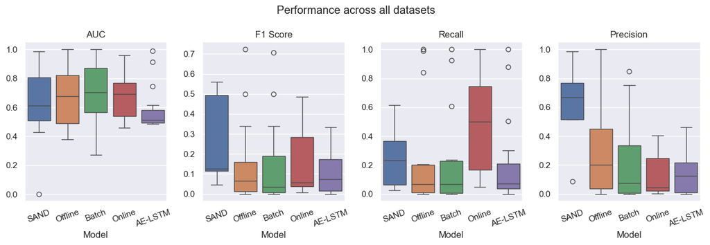

```python
boxplots_comparing_models(results_df, "Performance across all datasets")
```

### 4.1.3. Assessing the impact of anomaly ratio on model performance

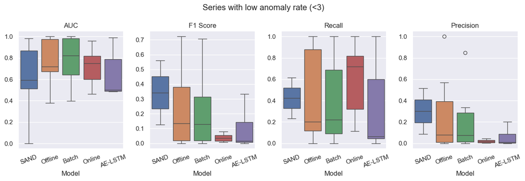

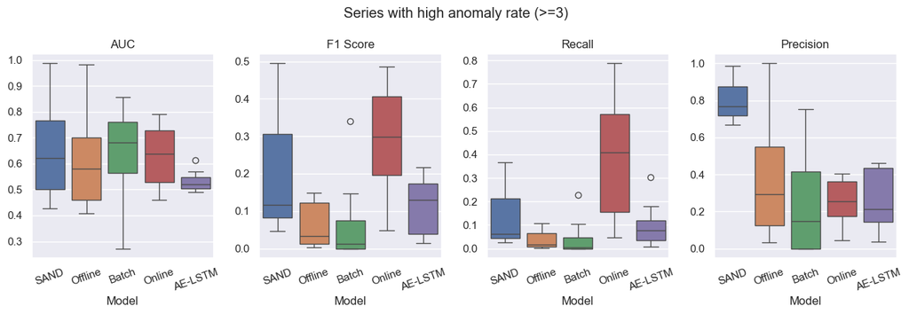

```python
boxplots_comparing_models(merged_results[merged_results['anomaly rate'] < 3], "Series with low anomaly rate (<3)")
boxplots_comparing_models(merged_results[merged_results['anomaly rate'] >= 3], "Series with high anomaly rate (>=3)")
```

### 4.1.4. Dataset characteristics/Model performance correlation

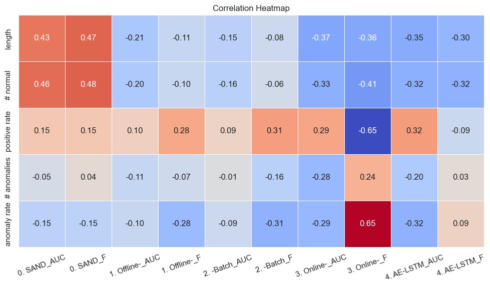

```python
correlations(merged_pivot, n_characteristics)
```

## 4.2. Normality 2 Results

```python
normality = 2
results_df = prepare_results_df(normality, 4, True)
results_df = results_df[results_df['datasets']!='Average']

pivot_map = get_datasets_x_model_pivot_table(results_df, save=False, print_=False).reset_index(drop=True)
```

```
selected datasets #  46
```

### 4.2.1. Characteristics of each double normality dataset

```python
data_info = get_k_normality_info(ALL_SETS, pivot_map[['datasets']].values.flatten(), 50000, True, False)
n_characteristics = len([col for col in data_info.columns if not col.startswith('si')]) - 1
data_info
```

|  | datasets | si length | si # normal | si positive rate | si # anomalies | si anomaly rate | length | # normal | # anomalies | anomaly rate | rate diff |
| --- | --- | --- | --- | --- | --- | --- | --- | --- | --- | --- | --- |
| 0 | ECG_GHL | [50000, 50000] | [47675, 49856] | [95.35, 99.71] | [2325, 144] | [4.65, 0.29] | 100000 | 97531 | 2469 | 2.47 | -4.36 |
| 1 | ECG_Genesis | [50000, 16220] | [47675, 16170] | [95.35, 99.69] | [2325, 50] | [4.65, 0.31] | 66220 | 63845 | 2375 | 3.59 | -4.34 |
| 2 | ECG_IOPS | [50000, 50000] | [47675, 49776] | [95.35, 99.55] | [2325, 224] | [4.65, 0.45] | 100000 | 97451 | 2549 | 2.55 | -4.20 |
| 3 | ECG_MGAB | [50000, 50000] | [47675, 49940] | [95.35, 99.88] | [2325, 60] | [4.65, 0.12] | 100000 | 97615 | 2385 | 2.38 | -4.53 |
| 4 | ECG_NAB | [50000, 2499] | [47675, 2253] | [95.35, 90.16] | [2325, 246] | [4.65, 9.84] | 52499 | 49928 | 2571 | 4.90 | 5.19 |
| 5 | ECG_OPPORTUNITY | [50000, 50000] | [47675, 48872] | [95.35, 97.74] | [2325, 1128] | [4.65, 2.26] | 100000 | 96547 | 3453 | 3.45 | -2.39 |
| 6 | ECG_SMD | [50000, 28479] | [47675, 25785] | [95.35, 90.54] | [2325, 2694] | [4.65, 9.46] | 78479 | 73460 | 5019 | 6.40 | 4.81 |
| 7 | ECG_SensorScope | [50000, 29553] | [47675, 25776] | [95.35, 87.22] | [2325, 3777] | [4.65, 12.78] | 79553 | 73451 | 6102 | 7.67 | 8.13 |
| 8 | ECG_YAHOO | [50000, 1420] | [47675, 1418] | [95.35, 99.86] | [2325, 2] | [4.65, 0.14] | 51420 | 49093 | 2327 | 4.53 | -4.51 |
| 9 | GHL_Genesis | [50000, 16220] | [49856, 16170] | [99.71, 99.69] | [144, 50] | [0.29, 0.31] | 66220 | 66026 | 194 | 0.29 | 0.02 |
| 10 | GHL_OPPORTUNITY | [50000, 50000] | [49856, 48872] | [99.71, 97.74] | [144, 1128] | [0.29, 2.26] | 100000 | 98728 | 1272 | 1.27 | 1.97 |
| 11 | GHL_SMD | [50000, 28479] | [49856, 25785] | [99.71, 90.54] | [144, 2694] | [0.29, 9.46] | 78479 | 75641 | 2838 | 3.62 | 9.17 |
| 12 | Genesis_OPPORTUNITY | [16220, 50000] | [16170, 48872] | [99.69, 97.74] | [50, 1128] | [0.31, 2.26] | 66220 | 65042 | 1178 | 1.78 | 1.95 |
| 13 | Genesis_SMD | [16220, 28479] | [16170, 25785] | [99.69, 90.54] | [50, 2694] | [0.31, 9.46] | 44699 | 41955 | 2744 | 6.14 | 9.15 |
| 14 | IOPS_GHL | [50000, 50000] | [49776, 49856] | [99.55, 99.71] | [224, 144] | [0.45, 0.29] | 100000 | 99632 | 368 | 0.37 | -0.16 |
| 15 | IOPS_Genesis | [50000, 16220] | [49776, 16170] | [99.55, 99.69] | [224, 50] | [0.45, 0.31] | 66220 | 65946 | 274 | 0.41 | -0.14 |
| 16 | IOPS_MGAB | [50000, 50000] | [49776, 49940] | [99.55, 99.88] | [224, 60] | [0.45, 0.12] | 100000 | 99716 | 284 | 0.28 | -0.33 |
| 17 | IOPS_NAB | [50000, 2499] | [49776, 2253] | [99.55, 90.16] | [224, 246] | [0.45, 9.84] | 52499 | 52029 | 470 | 0.90 | 9.39 |
| 18 | IOPS_OPPORTUNITY | [50000, 50000] | [49776, 48872] | [99.55, 97.74] | [224, 1128] | [0.45, 2.26] | 100000 | 98648 | 1352 | 1.35 | 1.81 |
| 19 | IOPS_SMD | [50000, 28479] | [49776, 25785] | [99.55, 90.54] | [224, 2694] | [0.45, 9.46] | 78479 | 75561 | 2918 | 3.72 | 9.01 |
| 20 | IOPS_SensorScope | [50000, 29553] | [49776, 25776] | [99.55, 87.22] | [224, 3777] | [0.45, 12.78] | 79553 | 75552 | 4001 | 5.03 | 12.33 |
| 21 | IOPS_YAHOO | [50000, 1420] | [49776, 1418] | [99.55, 99.86] | [224, 2] | [0.45, 0.14] | 51420 | 51194 | 226 | 0.44 | -0.31 |
| 22 | MGAB_GHL | [50000, 50000] | [49940, 49856] | [99.88, 99.71] | [60, 144] | [0.12, 0.29] | 100000 | 99796 | 204 | 0.20 | 0.17 |
| 23 | MGAB_Genesis | [50000, 16220] | [49940, 16170] | [99.88, 99.69] | [60, 50] | [0.12, 0.31] | 66220 | 66110 | 110 | 0.17 | 0.19 |
| 24 | MGAB_NAB | [50000, 2499] | [49940, 2253] | [99.88, 90.16] | [60, 246] | [0.12, 9.84] | 52499 | 52193 | 306 | 0.58 | 9.72 |
| 25 | MGAB_OPPORTUNITY | [50000, 50000] | [49940, 48872] | [99.88, 97.74] | [60, 1128] | [0.12, 2.26] | 100000 | 98812 | 1188 | 1.19 | 2.14 |
| 26 | MGAB_SMD | [50000, 28479] | [49940, 25785] | [99.88, 90.54] | [60, 2694] | [0.12, 9.46] | 78479 | 75725 | 2754 | 3.51 | 9.34 |
| 27 | MGAB_SensorScope | [50000, 29553] | [49940, 25776] | [99.88, 87.22] | [60, 3777] | [0.12, 12.78] | 79553 | 75716 | 3837 | 4.82 | 12.66 |
| 28 | MGAB_YAHOO | [50000, 1420] | [49940, 1418] | [99.88, 99.86] | [60, 2] | [0.12, 0.14] | 51420 | 51358 | 62 | 0.12 | 0.02 |
| 29 | MITDB_Occupancy | [50000, 8143] | [49641, 6414] | [99.28, 78.77] | [359, 1729] | [0.72, 21.23] | 58143 | 56055 | 2088 | 3.59 | 20.51 |
| 30 | NAB_GHL | [2499, 50000] | [2253, 49856] | [90.16, 99.71] | [246, 144] | [9.84, 0.29] | 52499 | 52109 | 390 | 0.74 | -9.55 |
| 31 | NAB_Genesis | [2499, 16220] | [2253, 16170] | [90.16, 99.69] | [246, 50] | [9.84, 0.31] | 18719 | 18423 | 296 | 1.58 | -9.53 |
| 32 | NAB_OPPORTUNITY | [2499, 50000] | [2253, 48872] | [90.16, 97.74] | [246, 1128] | [9.84, 2.26] | 52499 | 51125 | 1374 | 2.62 | -7.58 |
| 33 | NAB_SMD | [2499, 28479] | [2253, 25785] | [90.16, 90.54] | [246, 2694] | [9.84, 9.46] | 30978 | 28038 | 2940 | 9.49 | -0.38 |
| 34 | NAB_SensorScope | [2499, 29553] | [2253, 25776] | [90.16, 87.22] | [246, 3777] | [9.84, 12.78] | 32052 | 28029 | 4023 | 12.55 | 2.94 |
| 35 | NAB_YAHOO | [2499, 1420] | [2253, 1418] | [90.16, 99.86] | [246, 2] | [9.84, 0.14] | 3919 | 3671 | 248 | 6.33 | -9.70 |
| 36 | OPPORTUNITY_SMD | [50000, 28479] | [48872, 25785] | [97.74, 90.54] | [1128, 2694] | [2.26, 9.46] | 78479 | 74657 | 3822 | 4.87 | 7.20 |
| 37 | Occupancy_SVDB | [8143, 50000] | [6414, 23929] | [78.77, 47.86] | [1729, 26071] | [21.23, 52.14] | 58143 | 30343 | 27800 | 47.81 | 30.91 |
| 38 | SensorScope_GHL | [29553, 50000] | [25776, 49856] | [87.22, 99.71] | [3777, 144] | [12.78, 0.29] | 79553 | 75632 | 3921 | 4.93 | -12.49 |
| 39 | SensorScope_Genesis | [29553, 16220] | [25776, 16170] | [87.22, 99.69] | [3777, 50] | [12.78, 0.31] | 45773 | 41946 | 3827 | 8.36 | -12.47 |
| 40 | SensorScope_OPPORTUNITY | [29553, 50000] | [25776, 48872] | [87.22, 97.74] | [3777, 1128] | [12.78, 2.26] | 79553 | 74648 | 4905 | 6.17 | -10.52 |
| 41 | SensorScope_SMD | [29553, 28479] | [25776, 25785] | [87.22, 90.54] | [3777, 2694] | [12.78, 9.46] | 58032 | 51561 | 6471 | 11.15 | -3.32 |
| 42 | SensorScope_YAHOO | [29553, 1420] | [25776, 1418] | [87.22, 99.86] | [3777, 2] | [12.78, 0.14] | 30973 | 27194 | 3779 | 12.20 | -12.64 |
| 43 | YAHOO_GHL | [1420, 50000] | [1418, 49856] | [99.86, 99.71] | [2, 144] | [0.14, 0.29] | 51420 | 51274 | 146 | 0.28 | 0.15 |
| 44 | YAHOO_Genesis | [1420, 16220] | [1418, 16170] | [99.86, 99.69] | [2, 50] | [0.14, 0.31] | 17640 | 17588 | 52 | 0.29 | 0.17 |
| 45 | YAHOO_OPPORTUNITY | [1420, 50000] | [1418, 48872] | [99.86, 97.74] | [2, 1128] | [0.14, 2.26] | 51420 | 50290 | 1130 | 2.20 | 2.12 |

### 4.2.2. Results for each dataset and for each model

```python
merged_results = pd.merge(results_df, data_info, on='datasets')
merged_pivot = pd.merge(pivot_map, data_info, on='datasets')
```

```python
# all metrics per dataset/model combination
display_merged_results(merged_results)
```

| datasets | model | AUC | Precision | Recall | F | Precision@k | Rprecision | Rrecall | Rf | ExistenceReward | OverlapReward | RAUC | Accuracy | confusion_matrix | time | si length | si # normal | si positive rate | si # anomalies | si anomaly rate | length | # normal | # anomalies | anomaly rate | rate diff |
| --- | --- | --- | --- | --- | --- | --- | --- | --- | --- | --- | --- | --- | --- | --- | --- | --- | --- | --- | --- | --- | --- | --- | --- | --- | --- |
| ECG_Genesis | SAND | 91.25 | 0.00 | 0.00 | 0.00 | 0.00 | 0.00 | 0.00 | 0.00 | 0.00 | 0.00 | 91.15 | NaN | NaN | 40.643332 | [50000, 16220] | [47675, 16170] | [95.35, 99.69] | [2325, 50] | [4.65, 0.31] | 66220 | 63845 | 2375 | 3.59 | -4.34 |
|  | Offline-EncDec-AD | 47.54 | 2.50 | 2.43 | 2.47 | 2.43 | 0.34 | 8.75 | 0.66 | 11.11 | 8.16 | 52.92 | NaN | NaN | 167.172402 | [50000, 16220] | [47675, 16170] | [95.35, 99.69] | [2325, 50] | [4.65, 0.31] | 66220 | 63845 | 2375 | 3.59 | -4.34 |
|  | EncDec-AD-Batch | 51.15 | 0.00 | 0.00 | 0.00 | 0.00 | 0.00 | 0.00 | 0.00 | 0.00 | 0.00 | 56.46 | NaN | NaN | 232.007370 | [50000, 16220] | [47675, 16170] | [95.35, 99.69] | [2325, 50] | [4.65, 0.31] | 66220 | 63845 | 2375 | 3.59 | -4.34 |
|  | Online-EncDec-AD | 70.79 | 14.79 | 51.73 | 23.00 | 0.00 | 0.00 | 0.00 | 0.00 | 0.00 | 0.00 | 62.96 | 0.886019 | [[48855, 5515], [893, 957]] | 904.007082 | [50000, 16220] | [47675, 16170] | [95.35, 99.69] | [2325, 50] | [4.65, 0.31] | 66220 | 63845 | 2375 | 3.59 | -4.34 |
| ECG_GHL | SAND | 96.92 | 71.38 | 24.95 | 36.97 | 24.95 | 84.56 | 28.03 | 42.11 | 37.50 | 25.67 | 98.64 | NaN | NaN | 43.019001 | [50000, 50000] | [47675, 49856] | [95.35, 99.71] | [2325, 144] | [4.65, 0.29] | 100000 | 97531 | 2469 | 2.47 | -4.36 |
|  | Offline-EncDec-AD | 33.96 | 47.88 | 6.38 | 11.26 | 6.38 | 45.93 | 3.56 | 6.60 | 4.00 | 3.44 | 32.29 | NaN | NaN | 169.529581 | [50000, 50000] | [47675, 49856] | [95.35, 99.71] | [2325, 144] | [4.65, 0.29] | 100000 | 97531 | 2469 | 2.47 | -4.36 |
|  | EncDec-AD-Batch | 64.33 | 6.56 | 9.72 | 7.83 | 9.72 | 26.58 | 20.90 | 23.40 | 79.31 | 6.30 | 64.15 | NaN | NaN | 320.396568 | [50000, 50000] | [47675, 49856] | [95.35, 99.71] | [2325, 144] | [4.65, 0.29] | 100000 | 97531 | 2469 | 2.47 | -4.36 |
|  | Online-EncDec-AD | 69.69 | 8.02 | 52.73 | 13.92 | 0.00 | 0.00 | 0.00 | 0.00 | 0.00 | 0.00 | 62.52 | 0.859167 | [[76300, 11756], [919, 1025]] | 1408.083153 | [50000, 50000] | [47675, 49856] | [95.35, 99.71] | [2325, 144] | [4.65, 0.29] | 100000 | 97531 | 2469 | 2.47 | -4.36 |
| ECG_IOPS | SAND | 91.26 | 0.00 | 0.00 | 0.00 | 0.00 | 0.00 | 0.00 | 0.00 | 0.00 | 0.00 | 83.89 | NaN | NaN | 55.838218 | [50000, 50000] | [47675, 49776] | [95.35, 99.55] | [2325, 224] | [4.65, 0.45] | 100000 | 97451 | 2549 | 2.55 | -4.20 |
|  | Offline-EncDec-AD | 34.48 | 100.00 | 2.12 | 4.16 | 2.12 | 100.00 | 11.74 | 21.02 | 32.56 | 6.54 | 44.96 | NaN | NaN | 198.645178 | [50000, 50000] | [47675, 49776] | [95.35, 99.55] | [2325, 224] | [4.65, 0.45] | 100000 | 97451 | 2549 | 2.55 | -4.20 |
|  | EncDec-AD-Batch | 47.77 | 30.61 | 8.74 | 13.59 | 8.74 | 14.25 | 26.74 | 18.59 | 89.13 | 11.14 | 64.06 | NaN | NaN | 365.792831 | [50000, 50000] | [47675, 49776] | [95.35, 99.55] | [2325, 224] | [4.65, 0.45] | 100000 | 97451 | 2549 | 2.55 | -4.20 |
|  | Online-EncDec-AD | 67.46 | 6.50 | 52.17 | 11.56 | 0.00 | 0.00 | 0.00 | 0.00 | 0.00 | 0.00 | 58.53 | 0.820522 | [[72791, 15185], [968, 1056]] | 1584.055389 | [50000, 50000] | [47675, 49776] | [95.35, 99.55] | [2325, 224] | [4.65, 0.45] | 100000 | 97451 | 2549 | 2.55 | -4.20 |
| ECG_MGAB | SAND | 98.49 | 48.50 | 3.40 | 6.35 | 3.40 | 53.37 | 5.44 | 9.88 | 5.88 | 5.33 | 99.43 | NaN | NaN | 304.411109 | [50000, 50000] | [47675, 49940] | [95.35, 99.88] | [2325, 60] | [4.65, 0.12] | 100000 | 97615 | 2385 | 2.38 | -4.53 |
|  | AE-LSTM | 64.19 | 16.93 | 32.29 | 22.21 | 0.00 | 5.32 | 30.13 | 9.04 | 91.18 | 14.87 | 59.02 | 0.945525 | [[92837, 3778], [1615, 770]] | 2164.008618 | [50000, 50000] | [47675, 49940] | [95.35, 99.88] | [2325, 60] | [4.65, 0.12] | 100000 | 97615 | 2385 | 2.38 | -4.53 |
|  | Offline-EncDec-AD | 32.01 | 0.00 | 0.00 | 0.00 | 0.00 | 0.00 | 0.00 | 0.00 | 0.00 | 0.00 | 36.93 | NaN | NaN | 186.747190 | [50000, 50000] | [47675, 49940] | [95.35, 99.88] | [2325, 60] | [4.65, 0.12] | 100000 | 97615 | 2385 | 2.38 | -4.53 |
|  | EncDec-AD-Batch | 60.19 | 27.49 | 13.27 | 17.90 | 13.27 | 8.96 | 25.53 | 13.27 | 87.10 | 10.14 | 61.77 | NaN | NaN | 297.105618 | [50000, 50000] | [47675, 49940] | [95.35, 99.88] | [2325, 60] | [4.65, 0.12] | 100000 | 97615 | 2385 | 2.38 | -4.53 |
|  | Online-EncDec-AD | 70.78 | 11.21 | 49.89 | 18.31 | 0.00 | 3.20 | 36.46 | 5.89 | 92.59 | 22.42 | 63.05 | 0.907967 | [[80789, 7351], [932, 928]] | 1033.490946 | [50000, 50000] | [47675, 49940] | [95.35, 99.88] | [2325, 60] | [4.65, 0.12] | 100000 | 97615 | 2385 | 2.38 | -4.53 |
| ECG_NAB | SAND | 98.65 | 92.87 | 31.39 | 46.92 | 31.39 | 92.36 | 34.06 | 49.77 | 44.12 | 31.55 | 99.43 | NaN | NaN | 45.120925 | [50000, 2499] | [47675, 2253] | [95.35, 90.16] | [2325, 246] | [4.65, 9.84] | 52499 | 49928 | 2571 | 4.90 | 5.19 |
|  | Offline-EncDec-AD | 66.28 | 28.32 | 1.56 | 2.96 | 1.56 | 25.56 | 2.74 | 4.94 | 11.11 | 0.64 | 74.31 | NaN | NaN | 188.920267 | [50000, 2499] | [47675, 2253] | [95.35, 90.16] | [2325, 246] | [4.65, 9.84] | 52499 | 49928 | 2571 | 4.90 | 5.19 |
|  | EncDec-AD-Batch | 72.07 | 28.32 | 1.49 | 2.83 | 1.49 | 25.56 | 2.55 | 4.63 | 10.34 | 0.60 | 78.72 | NaN | NaN | 172.059000 | [50000, 2499] | [47675, 2253] | [95.35, 90.16] | [2325, 246] | [4.65, 9.84] | 52499 | 49928 | 2571 | 4.90 | 5.19 |
|  | Online-EncDec-AD | 69.96 | 22.33 | 48.44 | 30.57 | 0.00 | 0.00 | 0.00 | 0.00 | 0.00 | 0.00 | 64.21 | 0.894092 | [[37007, 3446], [1055, 991]] | 682.345092 | [50000, 2499] | [47675, 2253] | [95.35, 90.16] | [2325, 246] | [4.65, 9.84] | 52499 | 49928 | 2571 | 4.90 | 5.19 |
| ECG_OPPORTUNITY | SAND | 93.00 | 23.95 | 1.82 | 3.39 | 1.82 | 25.00 | 0.83 | 1.60 | 3.03 | 0.28 | 95.10 | NaN | NaN | 158.379523 | [50000, 50000] | [47675, 48872] | [95.35, 97.74] | [2325, 1128] | [4.65, 2.26] | 100000 | 96547 | 3453 | 3.45 | -2.39 |
|  | Offline-EncDec-AD | 56.31 | 69.38 | 38.39 | 49.43 | 38.39 | 2.47 | 7.67 | 3.74 | 7.69 | 7.66 | 36.97 | NaN | NaN | 192.508161 | [50000, 50000] | [47675, 48872] | [95.35, 97.74] | [2325, 1128] | [4.65, 2.26] | 100000 | 96547 | 3453 | 3.45 | -2.39 |
|  | EncDec-AD-Batch | 61.75 | 85.93 | 34.64 | 49.38 | 34.64 | 58.64 | 2.76 | 5.28 | 6.67 | 1.79 | 56.48 | NaN | NaN | 357.286777 | [50000, 50000] | [47675, 48872] | [95.35, 97.74] | [2325, 1128] | [4.65, 2.26] | 100000 | 96547 | 3453 | 3.45 | -2.39 |
|  | Online-EncDec-AD | 67.70 | 11.12 | 48.43 | 18.08 | 0.00 | 0.00 | 0.00 | 0.00 | 0.00 | 0.00 | 63.11 | 0.857233 | [[75733, 11339], [1510, 1418]] | 1549.749681 | [50000, 50000] | [47675, 48872] | [95.35, 97.74] | [2325, 1128] | [4.65, 2.26] | 100000 | 96547 | 3453 | 3.45 | -2.39 |
| ECG_SensorScope | SAND | 90.15 | 29.90 | 0.95 | 1.84 | 0.95 | 46.03 | 2.15 | 4.12 | 2.63 | 2.04 | 95.30 | NaN | NaN | 89.009936 | [50000, 29553] | [47675, 25776] | [95.35, 87.22] | [2325, 3777] | [4.65, 12.78] | 79553 | 73451 | 6102 | 7.67 | 8.13 |
|  | AE-LSTM | 54.82 | 18.64 | 15.24 | 16.77 | 15.24 | 9.54 | 27.82 | 14.20 | 89.47 | 12.41 | 54.61 | 0.882474 | [[68391, 4060], [5172, 930]] | 2612.265761 | [50000, 29553] | [47675, 25776] | [95.35, 87.22] | [2325, 3777] | [4.65, 12.78] | 79553 | 73451 | 6102 | 7.67 | 8.13 |
|  | Offline-EncDec-AD | 74.41 | 43.32 | 1.45 | 2.81 | 1.45 | 29.76 | 0.66 | 1.28 | 3.23 | 0.01 | 72.77 | NaN | NaN | 185.205666 | [50000, 29553] | [47675, 25776] | [95.35, 87.22] | [2325, 3777] | [4.65, 12.78] | 79553 | 73451 | 6102 | 7.67 | 8.13 |
|  | EncDec-AD-Batch | 67.43 | 0.00 | 0.00 | 0.00 | 0.00 | 0.00 | 0.00 | 0.00 | 0.00 | 0.00 | 67.18 | NaN | NaN | 288.375719 | [50000, 29553] | [47675, 25776] | [95.35, 87.22] | [2325, 3777] | [4.65, 12.78] | 79553 | 73451 | 6102 | 7.67 | 8.13 |
|  | Online-EncDec-AD | 71.02 | 29.38 | 53.18 | 37.85 | 0.00 | 0.00 | 0.00 | 0.00 | 0.00 | 0.00 | 68.73 | 0.859963 | [[56847, 7129], [2611, 2966]] | 1114.151441 | [50000, 29553] | [47675, 25776] | [95.35, 87.22] | [2325, 3777] | [4.65, 12.78] | 79553 | 73451 | 6102 | 7.67 | 8.13 |

[output cut: 167 more lines]

```python
# AUC and F1 scores per dataset and model
pivot_map
```

|  | datasets | 0. SAND_AUC | 0. SAND_F | 1. Offline-EncDec-AD_AUC | 1. Offline-EncDec-AD_F | 2. EncDec-AD-Batch_AUC | 2. EncDec-AD-Batch_F | 3. Online-EncDec-AD_AUC | 3. Online-EncDec-AD_F | 4. AE-LSTM_AUC | 4. AE-LSTM_F |
| --- | --- | --- | --- | --- | --- | --- | --- | --- | --- | --- | --- |
| 0 | ECG_GHL | 96.92 | 36.97 | 33.96 | 11.26 | 64.33 | 7.83 | 69.69 | 13.92 | NaN | NaN |
| 1 | ECG_Genesis | 91.25 | 0.00 | 47.54 | 2.47 | 51.15 | 0.00 | 70.79 | 23.00 | NaN | NaN |
| 2 | ECG_IOPS | 91.26 | 0.00 | 34.48 | 4.16 | 47.77 | 13.59 | 67.46 | 11.56 | NaN | NaN |
| 3 | ECG_MGAB | 98.49 | 6.35 | 32.01 | 0.00 | 60.19 | 17.90 | 70.78 | 18.31 | 64.19 | 22.21 |
| 4 | ECG_NAB | 98.65 | 46.92 | 66.28 | 2.96 | 72.07 | 2.83 | 69.96 | 30.57 | NaN | NaN |
| 5 | ECG_OPPORTUNITY | 93.00 | 3.39 | 56.31 | 49.43 | 61.75 | 49.38 | 67.70 | 18.08 | NaN | NaN |
| 6 | ECG_SMD | 60.69 | 2.90 | 73.90 | 14.12 | 78.40 | 9.53 | 64.44 | 20.30 | 55.98 | 17.66 |
| 7 | ECG_SensorScope | 90.15 | 1.84 | 74.41 | 2.81 | 67.43 | 0.00 | 71.02 | 37.85 | 54.82 | 16.77 |
| 8 | ECG_YAHOO | 96.45 | 24.21 | 64.39 | 13.73 | 70.95 | 14.71 | 71.57 | 30.63 | NaN | NaN |
| 9 | GHL_Genesis | 23.64 | 0.00 | 63.51 | 4.52 | 88.08 | 0.00 | 69.24 | 2.09 | NaN | NaN |
| 10 | GHL_OPPORTUNITY | 83.64 | 0.00 | 92.29 | 77.84 | 99.85 | 80.65 | 63.48 | 6.42 | NaN | NaN |
| 11 | GHL_SMD | 42.93 | 0.00 | 21.16 | 0.00 | 70.12 | 0.00 | 63.10 | 12.56 | NaN | NaN |
| 12 | Genesis_OPPORTUNITY | 77.18 | 0.00 | 99.07 | 70.69 | 98.65 | 69.97 | 54.63 | 5.41 | 50.76 | 3.37 |
| 13 | Genesis_SMD | 51.32 | 0.00 | 90.80 | 2.45 | 57.05 | 0.00 | 57.38 | 14.90 | NaN | NaN |
| 14 | IOPS_GHL | 49.85 | 0.00 | 47.71 | 20.88 | 88.33 | 12.20 | 68.47 | 1.83 | NaN | NaN |
| 15 | IOPS_Genesis | 42.93 | 0.00 | 66.04 | 4.50 | 69.06 | 0.00 | 69.34 | 2.05 | NaN | NaN |
| 16 | IOPS_MGAB | 74.74 | 10.81 | 56.47 | 25.27 | 73.26 | 25.16 | 64.31 | 1.38 | NaN | NaN |
| 17 | IOPS_NAB | 53.30 | 0.00 | 86.83 | 10.96 | 83.75 | 10.25 | 53.47 | 2.41 | 63.26 | 20.33 |
| 18 | IOPS_OPPORTUNITY | 75.49 | 0.00 | 91.92 | 79.52 | 93.29 | 82.49 | 63.58 | 5.92 | NaN | NaN |
| 19 | IOPS_SMD | 34.61 | 0.00 | 63.05 | 2.34 | 40.00 | 0.53 | 58.04 | 10.46 | 51.26 | 5.36 |
| 20 | IOPS_SensorScope | 39.19 | 0.00 | 68.79 | 3.27 | 51.92 | 0.00 | 68.53 | 21.85 | NaN | NaN |
| 21 | IOPS_YAHOO | 36.85 | 0.00 | 73.74 | 40.85 | 67.54 | 4.35 | 65.12 | 1.78 | NaN | NaN |
| 22 | MGAB_GHL | 62.49 | 0.00 | 79.12 | 14.17 | 84.77 | 7.12 | 71.95 | 1.89 | NaN | NaN |
| 23 | MGAB_Genesis | 25.74 | 0.00 | 68.65 | 4.71 | 68.55 | 0.00 | 68.07 | 1.86 | NaN | NaN |
| 24 | MGAB_NAB | 82.88 | 36.48 | 90.39 | 15.27 | 92.07 | 16.08 | 54.14 | 2.62 | NaN | NaN |
| 25 | MGAB_OPPORTUNITY | 88.34 | 0.00 | 96.27 | 80.20 | 96.14 | 88.33 | 58.23 | 5.61 | 48.54 | 0.54 |
| 26 | MGAB_SMD | 41.99 | 0.00 | 61.22 | 0.00 | 73.55 | 4.00 | 66.67 | 14.47 | NaN | NaN |
| 27 | MGAB_SensorScope | 71.00 | 2.21 | 84.85 | 4.03 | 74.11 | 0.00 | 68.86 | 29.56 | NaN | NaN |
| 28 | MGAB_YAHOO | 54.98 | 0.28 | 60.02 | 0.00 | 50.62 | 0.00 | 51.24 | 0.38 | NaN | NaN |
| 29 | MITDB_Occupancy | 87.25 | 0.80 | 99.87 | 97.14 | 84.77 | 54.20 | 75.36 | 21.54 | 49.14 | 3.67 |
| 30 | NAB_GHL | 69.39 | 0.00 | 18.75 | 10.96 | 89.94 | 0.00 | 58.45 | 2.17 | NaN | NaN |
| 31 | NAB_Genesis | 69.28 | 0.00 | 55.31 | 14.12 | 70.18 | 13.55 | 65.98 | 9.02 | NaN | NaN |
| 32 | NAB_OPPORTUNITY | 82.51 | 0.00 | 91.80 | 3.11 | 93.59 | 0.00 | 50.09 | 4.29 | NaN | NaN |
| 33 | NAB_SMD | 47.53 | 0.00 | 38.83 | 1.31 | 62.82 | 0.00 | 53.56 | 18.00 | NaN | NaN |
| 34 | NAB_SensorScope | 61.67 | 0.00 | 32.46 | 0.95 | 72.40 | 0.00 | 67.36 | 39.18 | NaN | NaN |
| 35 | NAB_YAHOO | 47.30 | 0.00 | 40.64 | 6.52 | 60.34 | 2.23 | 61.12 | 18.21 | 59.72 | 26.23 |
| 36 | OPPORTUNITY_SMD | 56.95 | 0.00 | 58.59 | 21.33 | 31.30 | 0.06 | 62.76 | 13.77 | NaN | NaN |
| 37 | Occupancy_SVDB | 31.63 | 0.00 | 56.59 | 2.65 | 45.31 | 3.37 | 55.45 | 26.92 | 52.67 | 12.68 |
| 38 | SensorScope_GHL | 48.20 | 0.00 | 46.38 | 4.89 | 88.72 | 4.34 | 76.94 | 19.81 | 52.62 | 9.97 |
| 39 | SensorScope_Genesis | 44.91 | 0.00 | 26.96 | 2.44 | 58.15 | 0.00 | 79.38 | 37.24 | NaN | NaN |
| 40 | SensorScope_OPPORTUNITY | 54.53 | 0.00 | 42.80 | 45.54 | 81.77 | 1.83 | 73.47 | 26.73 | NaN | NaN |
| 41 | SensorScope_SMD | 45.64 | 0.00 | 63.63 | 2.32 | 65.76 | 0.00 | 69.61 | 29.62 | 54.11 | 16.10 |
| 42 | SensorScope_YAHOO | 49.19 | 0.00 | 43.31 | 4.40 | 85.38 | 4.27 | 79.12 | 46.92 | NaN | NaN |
| 43 | YAHOO_GHL | 85.00 | 0.00 | 98.45 | 48.89 | 87.56 | 0.00 | 89.38 | 2.63 | NaN | NaN |
| 44 | YAHOO_Genesis | 3.29 | 0.00 | 93.40 | 16.22 | 94.89 | 0.00 | 90.22 | 3.94 | 80.62 | 8.77 |
| 45 | YAHOO_OPPORTUNITY | 91.69 | 0.00 | 99.72 | 89.73 | 88.50 | 0.00 | 53.46 | 5.57 | NaN | NaN |

```python
# average values per model
avg_values = prepare_results_df(normality, 5, True).query("datasets == 'Average'")
display_avg_values(avg_values)
```

```
selected datasets #  13
```

|  | model | AUC | Precision | Recall | F | Precision@k | Rprecision | Rrecall | Rf | ExistenceReward | OverlapReward | RAUC | time |
| --- | --- | --- | --- | --- | --- | --- | --- | --- | --- | --- | --- | --- | --- |
| 65 | SAND | 58.93 | 8.74 | 0.51 | 0.92 | 0.51 | 12.30 | 1.21 | 1.68 | 1.60 | 1.12 | 63.76 | 51.395003 |
| 68 | Offline-EncDec-AD | 71.23 | 50.11 | 30.70 | 23.91 | 30.70 | 34.10 | 23.57 | 12.08 | 40.95 | 19.22 | 70.31 | 128.229059 |
| 67 | EncDec-AD-Batch | 74.18 | 38.83 | 16.86 | 20.05 | 16.86 | 31.03 | 15.76 | 15.29 | 34.86 | 10.99 | 74.26 | 214.603721 |
| 69 | Online-EncDec-AD | 66.10 | 15.11 | 51.22 | 16.95 | 0.00 | 0.25 | 2.80 | 0.45 | 7.12 | 1.72 | 65.30 | 702.393672 |
| 66 | AE-LSTM | 56.75 | 20.30 | 16.90 | 12.59 | 5.05 | 14.71 | 29.78 | 11.99 | 76.06 | 18.21 | 55.79 | 2238.639645 |

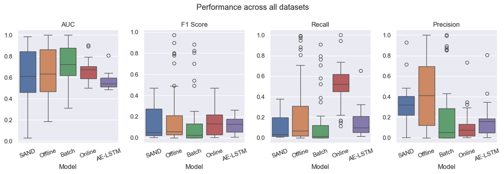

```python
boxplots_comparing_models(results_df, "Performance across all datasets")
```

### 4.2.3. Assessing the impact of different anomaly ratio trends on model performance

```python
sorted_merged_pivot = pd.concat([
    merged_pivot[merged_pivot['rate diff'] < 0].sort_values(by=['rate diff'], ascending=False),
    merged_pivot[merged_pivot['rate diff'] > 0].sort_values(by=['rate diff'])
])
sorted_merged_pivot = sorted_merged_pivot.dropna(subset=['4. AE-LSTM_AUC'])
sorted_merged_pivot.reset_index(drop=True)
```

|  | datasets | 0. SAND_AUC | 0. SAND_F | 1. Offline-EncDec-AD_AUC | 1. Offline-EncDec-AD_F | 2. EncDec-AD-Batch_AUC | 2. EncDec-AD-Batch_F | 3. Online-EncDec-AD_AUC | 3. Online-EncDec-AD_F | 4. AE-LSTM_AUC | 4. AE-LSTM_F | si length | si # normal | si positive rate | si # anomalies | si anomaly rate | length | # normal | # anomalies | anomaly rate | rate diff |
| --- | --- | --- | --- | --- | --- | --- | --- | --- | --- | --- | --- | --- | --- | --- | --- | --- | --- | --- | --- | --- | --- |
| 0 | SensorScope_SMD | 45.64 | 0.00 | 63.63 | 2.32 | 65.76 | 0.00 | 69.61 | 29.62 | 54.11 | 16.10 | [29553, 28479] | [25776, 25785] | [87.22, 90.54] | [3777, 2694] | [12.78, 9.46] | 58032 | 51561 | 6471 | 11.15 | -3.32 |
| 1 | ECG_MGAB | 98.49 | 6.35 | 32.01 | 0.00 | 60.19 | 17.90 | 70.78 | 18.31 | 64.19 | 22.21 | [50000, 50000] | [47675, 49940] | [95.35, 99.88] | [2325, 60] | [4.65, 0.12] | 100000 | 97615 | 2385 | 2.38 | -4.53 |
| 2 | NAB_YAHOO | 47.30 | 0.00 | 40.64 | 6.52 | 60.34 | 2.23 | 61.12 | 18.21 | 59.72 | 26.23 | [2499, 1420] | [2253, 1418] | [90.16, 99.86] | [246, 2] | [9.84, 0.14] | 3919 | 3671 | 248 | 6.33 | -9.70 |
| 3 | SensorScope_GHL | 48.20 | 0.00 | 46.38 | 4.89 | 88.72 | 4.34 | 76.94 | 19.81 | 52.62 | 9.97 | [29553, 50000] | [25776, 49856] | [87.22, 99.71] | [3777, 144] | [12.78, 0.29] | 79553 | 75632 | 3921 | 4.93 | -12.49 |
| 4 | YAHOO_Genesis | 3.29 | 0.00 | 93.40 | 16.22 | 94.89 | 0.00 | 90.22 | 3.94 | 80.62 | 8.77 | [1420, 16220] | [1418, 16170] | [99.86, 99.69] | [2, 50] | [0.14, 0.31] | 17640 | 17588 | 52 | 0.29 | 0.17 |
| 5 | Genesis_OPPORTUNITY | 77.18 | 0.00 | 99.07 | 70.69 | 98.65 | 69.97 | 54.63 | 5.41 | 50.76 | 3.37 | [16220, 50000] | [16170, 48872] | [99.69, 97.74] | [50, 1128] | [0.31, 2.26] | 66220 | 65042 | 1178 | 1.78 | 1.95 |
| 6 | MGAB_OPPORTUNITY | 88.34 | 0.00 | 96.27 | 80.20 | 96.14 | 88.33 | 58.23 | 5.61 | 48.54 | 0.54 | [50000, 50000] | [49940, 48872] | [99.88, 97.74] | [60, 1128] | [0.12, 2.26] | 100000 | 98812 | 1188 | 1.19 | 2.14 |
| 7 | ECG_SMD | 60.69 | 2.90 | 73.90 | 14.12 | 78.40 | 9.53 | 64.44 | 20.30 | 55.98 | 17.66 | [50000, 28479] | [47675, 25785] | [95.35, 90.54] | [2325, 2694] | [4.65, 9.46] | 78479 | 73460 | 5019 | 6.40 | 4.81 |
| 8 | ECG_SensorScope | 90.15 | 1.84 | 74.41 | 2.81 | 67.43 | 0.00 | 71.02 | 37.85 | 54.82 | 16.77 | [50000, 29553] | [47675, 25776] | [95.35, 87.22] | [2325, 3777] | [4.65, 12.78] | 79553 | 73451 | 6102 | 7.67 | 8.13 |
| 9 | IOPS_SMD | 34.61 | 0.00 | 63.05 | 2.34 | 40.00 | 0.53 | 58.04 | 10.46 | 51.26 | 5.36 | [50000, 28479] | [49776, 25785] | [99.55, 90.54] | [224, 2694] | [0.45, 9.46] | 78479 | 75561 | 2918 | 3.72 | 9.01 |
| 10 | IOPS_NAB | 53.30 | 0.00 | 86.83 | 10.96 | 83.75 | 10.25 | 53.47 | 2.41 | 63.26 | 20.33 | [50000, 2499] | [49776, 2253] | [99.55, 90.16] | [224, 246] | [0.45, 9.84] | 52499 | 52029 | 470 | 0.90 | 9.39 |
| 11 | MITDB_Occupancy | 87.25 | 0.80 | 99.87 | 97.14 | 84.77 | 54.20 | 75.36 | 21.54 | 49.14 | 3.67 | [50000, 8143] | [49641, 6414] | [99.28, 78.77] | [359, 1729] | [0.72, 21.23] | 58143 | 56055 | 2088 | 3.59 | 20.51 |
| 12 | Occupancy_SVDB | 31.63 | 0.00 | 56.59 | 2.65 | 45.31 | 3.37 | 55.45 | 26.92 | 52.67 | 12.68 | [8143, 50000] | [6414, 23929] | [78.77, 47.86] | [1729, 26071] | [21.23, 52.14] | 58143 | 30343 | 27800 | 47.81 | 30.91 |

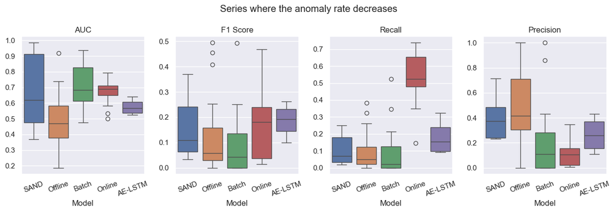

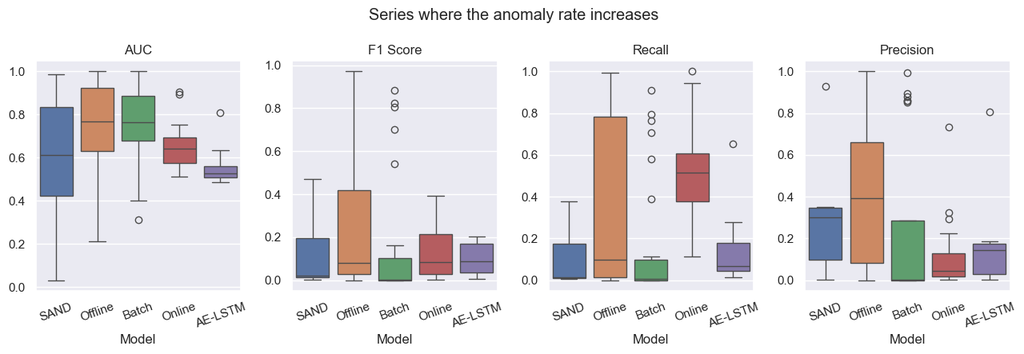

```python
boxplots_comparing_models(merged_results[merged_results['rate diff'] < 0], "Series where the anomaly rate decreases")
boxplots_comparing_models(merged_results[merged_results['rate diff'] > 0], "Series where the anomaly rate increases")
```

### 4.2.4. Dataset characteristics/Model performance correlation

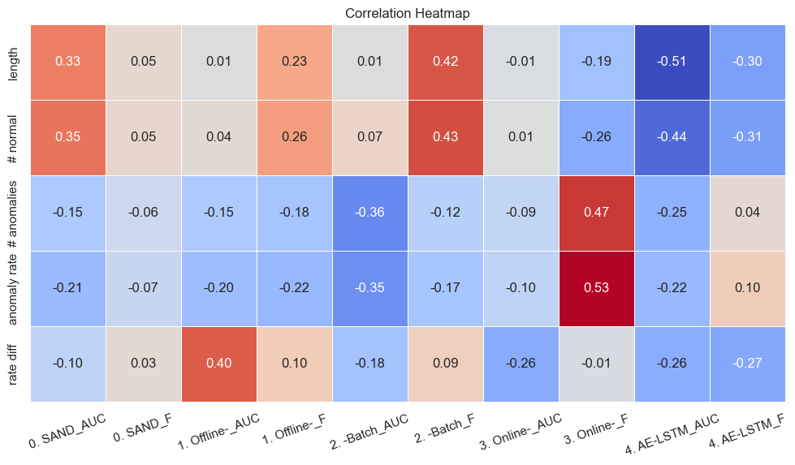

```python
# partial corr matrix
correlations(merged_pivot, n_characteristics)
```

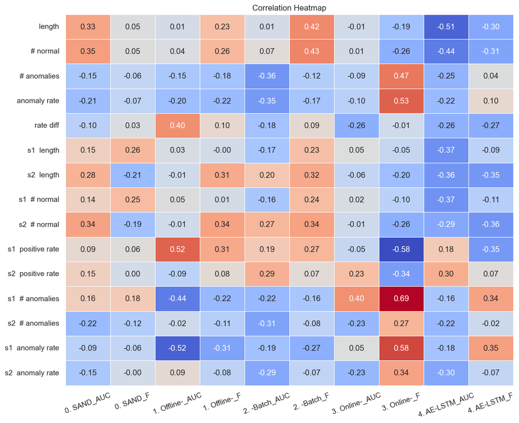

```python
# full corr matrix
merged_pivot_split = split_list_columns(merged_pivot)
n_characteristics = len([col for col in merged_pivot_split.columns if not col[0].isdigit() and col!='datasets'])
correlations(merged_pivot_split, n_characteristics)
```

## 4.3. Normality 3 Results

```python
normality = 3
results_df = prepare_results_df(normality, 5, True)

avg_values = results_df[results_df['datasets']=='Average']
results_df = results_df[results_df['datasets']!='Average']

pivot_map = get_datasets_x_model_pivot_table(results_df, save=False, print_=False).reset_index(drop=True)
```

```
selected datasets #  28
```

### 4.3.1. Characteristics of each triple normality dataset

```python
data_info = get_k_normality_info(ALL_SETS, pivot_map[['datasets']].values.flatten(), 50000, True, False)
n_characteristics = len([col for col in data_info.columns if not col.startswith('si')]) - 1
data_info
```

|  | datasets | si length | si # normal | si positive rate | si # anomalies | si anomaly rate | length | # normal | # anomalies | anomaly rate | rate diff |
| --- | --- | --- | --- | --- | --- | --- | --- | --- | --- | --- | --- |
| 0 | ECG_OPPORTUNITY_MGAB | [50000, 50000, 50000] | [47675, 48872, 49940] | [95.35, 97.74, 99.88] | [2325, 1128, 60] | [4.65, 2.26, 0.12] | 150000 | 146487 | 3513 | 2.34 | -4.53 |
| 1 | ECG_SMD_SensorScope | [50000, 28479, 29553] | [47675, 25785, 25776] | [95.35, 90.54, 87.22] | [2325, 2694, 3777] | [4.65, 9.46, 12.78] | 108032 | 99236 | 8796 | 8.14 | 8.13 |
| 2 | GHL_ECG_SensorScope | [50000, 50000, 29553] | [49856, 47675, 25776] | [99.71, 95.35, 87.22] | [144, 2325, 3777] | [0.29, 4.65, 12.78] | 129553 | 123307 | 6246 | 4.82 | 12.49 |
| 3 | GHL_SMD_SensorScope | [50000, 28479, 29553] | [49856, 25785, 25776] | [99.71, 90.54, 87.22] | [144, 2694, 3777] | [0.29, 9.46, 12.78] | 108032 | 101417 | 6615 | 6.12 | 12.49 |
| 4 | IOPS_ECG_SMD | [50000, 50000, 28479] | [49776, 47675, 25785] | [99.55, 95.35, 90.54] | [224, 2325, 2694] | [0.45, 4.65, 9.46] | 128479 | 123236 | 5243 | 4.08 | 9.01 |
| 5 | IOPS_SMD_NAB | [50000, 28479, 2499] | [49776, 25785, 2253] | [99.55, 90.54, 90.16] | [224, 2694, 246] | [0.45, 9.46, 9.84] | 80978 | 77814 | 3164 | 3.91 | 9.39 |
| 6 | IOPS_SMD_SensorScope | [50000, 28479, 29553] | [49776, 25785, 25776] | [99.55, 90.54, 87.22] | [224, 2694, 3777] | [0.45, 9.46, 12.78] | 108032 | 101337 | 6695 | 6.20 | 12.33 |
| 7 | MGAB_ECG_SMD | [50000, 50000, 28479] | [49940, 47675, 25785] | [99.88, 95.35, 90.54] | [60, 2325, 2694] | [0.12, 4.65, 9.46] | 128479 | 123400 | 5079 | 3.95 | 9.34 |
| 8 | MGAB_ECG_SensorScope | [50000, 50000, 29553] | [49940, 47675, 25776] | [99.88, 95.35, 87.22] | [60, 2325, 3777] | [0.12, 4.65, 12.78] | 129553 | 123391 | 6162 | 4.76 | 12.66 |
| 9 | MGAB_Genesis_OPPORTUNITY | [50000, 16220, 50000] | [49940, 16170, 48872] | [99.88, 99.69, 97.74] | [60, 50, 1128] | [0.12, 0.31, 2.26] | 116220 | 114982 | 1238 | 1.07 | 2.14 |
| 10 | MGAB_OPPORTUNITY_ECG | [50000, 50000, 50000] | [49940, 48872, 47675] | [99.88, 97.74, 95.35] | [60, 1128, 2325] | [0.12, 2.26, 4.65] | 150000 | 146487 | 3513 | 2.34 | 4.53 |
| 11 | MITDB_Occupancy_SVDB | [50000, 8143, 50000] | [49641, 6414, 23929] | [99.28, 78.77, 47.86] | [359, 1729, 26071] | [0.72, 21.23, 52.14] | 108143 | 79984 | 28159 | 26.04 | 51.42 |
| 12 | NAB_Genesis_YAHOO | [2499, 16220, 1420] | [2253, 16170, 1418] | [90.16, 99.69, 99.86] | [246, 50, 2] | [9.84, 0.31, 0.14] | 20139 | 19841 | 298 | 1.48 | -9.70 |
| 13 | NAB_IOPS_YAHOO | [2499, 50000, 1420] | [2253, 49776, 1418] | [90.16, 99.55, 99.86] | [246, 224, 2] | [9.84, 0.45, 0.14] | 53919 | 53447 | 472 | 0.88 | -9.70 |
| 14 | NAB_SMD_IOPS | [2499, 28479, 50000] | [2253, 25785, 49776] | [90.16, 90.54, 99.55] | [246, 2694, 224] | [9.84, 9.46, 0.45] | 80978 | 77814 | 3164 | 3.91 | -9.39 |
| 15 | OPPORTUNITY_Genesis_MGAB | [50000, 16220, 50000] | [48872, 16170, 49940] | [97.74, 99.69, 99.88] | [1128, 50, 60] | [2.26, 0.31, 0.12] | 116220 | 114982 | 1238 | 1.07 | -2.14 |
| 16 | OPPORTUNITY_Genesis_YAHOO | [50000, 16220, 1420] | [48872, 16170, 1418] | [97.74, 99.69, 99.86] | [1128, 50, 2] | [2.26, 0.31, 0.14] | 67640 | 66460 | 1180 | 1.74 | -2.12 |
| 17 | SMD_ECG_IOPS | [28479, 50000, 50000] | [25785, 47675, 49776] | [90.54, 95.35, 99.55] | [2694, 2325, 224] | [9.46, 4.65, 0.45] | 128479 | 123236 | 5243 | 4.08 | -9.01 |
| 18 | SMD_ECG_MGAB | [28479, 50000, 50000] | [25785, 47675, 49940] | [90.54, 95.35, 99.88] | [2694, 2325, 60] | [9.46, 4.65, 0.12] | 128479 | 123400 | 5079 | 3.95 | -9.34 |
| 19 | SVDB_Occupancy_MITDB | [50000, 8143, 50000] | [23929, 6414, 49641] | [47.86, 78.77, 99.28] | [26071, 1729, 359] | [52.14, 21.23, 0.72] | 108143 | 79984 | 28159 | 26.04 | -51.42 |
| 20 | SensorScope_ECG_GHL | [29553, 50000, 50000] | [25776, 47675, 49856] | [87.22, 95.35, 99.71] | [3777, 2325, 144] | [12.78, 4.65, 0.29] | 129553 | 123307 | 6246 | 4.82 | -12.49 |
| 21 | SensorScope_ECG_MGAB | [29553, 50000, 50000] | [25776, 47675, 49940] | [87.22, 95.35, 99.88] | [3777, 2325, 60] | [12.78, 4.65, 0.12] | 129553 | 123391 | 6162 | 4.76 | -12.66 |
| 22 | SensorScope_SMD_ECG | [29553, 28479, 50000] | [25776, 25785, 47675] | [87.22, 90.54, 95.35] | [3777, 2694, 2325] | [12.78, 9.46, 4.65] | 108032 | 99236 | 8796 | 8.14 | -8.13 |
| 23 | SensorScope_SMD_GHL | [29553, 28479, 50000] | [25776, 25785, 49856] | [87.22, 90.54, 99.71] | [3777, 2694, 144] | [12.78, 9.46, 0.29] | 108032 | 101417 | 6615 | 6.12 | -12.49 |
| 24 | SensorScope_SMD_IOPS | [29553, 28479, 50000] | [25776, 25785, 49776] | [87.22, 90.54, 99.55] | [3777, 2694, 224] | [12.78, 9.46, 0.45] | 108032 | 101337 | 6695 | 6.20 | -12.33 |
| 25 | YAHOO_Genesis_NAB | [1420, 16220, 2499] | [1418, 16170, 2253] | [99.86, 99.69, 90.16] | [2, 50, 246] | [0.14, 0.31, 9.84] | 20139 | 19841 | 298 | 1.48 | 9.70 |
| 26 | YAHOO_Genesis_OPPORTUNITY | [1420, 16220, 50000] | [1418, 16170, 48872] | [99.86, 99.69, 97.74] | [2, 50, 1128] | [0.14, 0.31, 2.26] | 67640 | 66460 | 1180 | 1.74 | 2.12 |
| 27 | YAHOO_IOPS_NAB | [1420, 50000, 2499] | [1418, 49776, 2253] | [99.86, 99.55, 90.16] | [2, 224, 246] | [0.14, 0.45, 9.84] | 53919 | 53447 | 472 | 0.88 | 9.70 |

### 4.3.2. Results for each dataset and for each model

```python
merged_results = pd.merge(results_df, data_info, on='datasets')
merged_pivot = pd.merge(pivot_map, data_info, on='datasets')
```

```python
# all metrics per dataset/model combination
display_merged_results(merged_results)
```

| datasets | model | AUC | Precision | Recall | F | Precision@k | Rprecision | Rrecall | Rf | ExistenceReward | OverlapReward | RAUC | Accuracy | confusion_matrix | time | si length | si # normal | si positive rate | si # anomalies | si anomaly rate | length | # normal | # anomalies | anomaly rate | rate diff |
| --- | --- | --- | --- | --- | --- | --- | --- | --- | --- | --- | --- | --- | --- | --- | --- | --- | --- | --- | --- | --- | --- | --- | --- | --- | --- |
| ECG_OPPORTUNITY_MGAB | SAND | 92.87 | 16.39 | 0.57 | 1.10 | 0.57 | 14.93 | 2.78 | 4.68 | 2.78 | 2.78 | 93.91 | NaN | NaN | 226.708814 | [50000, 50000, 50000] | [47675, 48872, 49940] | [95.35, 97.74, 99.88] | [2325, 1128, 60] | [4.65, 2.26, 0.12] | 150000 | 146487 | 3513 | 2.34 | -4.53 |
|  | AE-LSTM | 58.63 | 11.87 | 21.04 | 15.18 | 0.00 | 3.60 | 28.60 | 6.39 | 88.89 | 13.53 | 56.91 | 0.944570 | [[140002, 5485], [2774, 739]] | 4617.227303 | [50000, 50000, 50000] | [47675, 48872, 49940] | [95.35, 97.74, 99.88] | [2325, 1128, 60] | [4.65, 2.26, 0.12] | 150000 | 146487 | 3513 | 2.34 | -4.53 |
|  | Offline-EncDec-AD | 50.65 | 58.52 | 37.68 | 45.85 | 37.68 | 2.73 | 5.51 | 3.65 | 6.90 | 5.16 | 32.80 | NaN | NaN | 170.760789 | [50000, 50000, 50000] | [47675, 48872, 49940] | [95.35, 97.74, 99.88] | [2325, 1128, 60] | [4.65, 2.26, 0.12] | 150000 | 146487 | 3513 | 2.34 | -4.53 |
|  | EncDec-AD-Batch | 65.38 | 83.99 | 22.99 | 36.10 | 22.99 | 19.54 | 3.45 | 5.86 | 3.45 | 3.45 | 58.67 | NaN | NaN | 318.609342 | [50000, 50000, 50000] | [47675, 48872, 49940] | [95.35, 97.74, 99.88] | [2325, 1128, 60] | [4.65, 2.26, 0.12] | 150000 | 146487 | 3513 | 2.34 | -4.53 |
|  | Online-EncDec-AD | 68.17 | 8.43 | 47.62 | 14.32 | 0.00 | 0.00 | 0.00 | 0.00 | 0.00 | 0.00 | 63.28 | 0.878371 | [[121549, 15463], [1565, 1423]] | 1646.948857 | [50000, 50000, 50000] | [47675, 48872, 49940] | [95.35, 97.74, 99.88] | [2325, 1128, 60] | [4.65, 2.26, 0.12] | 150000 | 146487 | 3513 | 2.34 | -4.53 |
| ECG_SMD_SensorScope | SAND | 62.00 | 68.89 | 1.76 | 3.44 | 1.76 | 71.80 | 5.89 | 10.89 | 13.04 | 4.10 | 78.22 | NaN | NaN | 77.267959 | [50000, 28479, 29553] | [47675, 25785, 25776] | [95.35, 90.54, 87.22] | [2325, 2694, 3777] | [4.65, 9.46, 12.78] | 108032 | 99236 | 8796 | 8.14 | 8.13 |
|  | AE-LSTM | 54.50 | 20.40 | 13.82 | 16.48 | 13.82 | 8.50 | 25.38 | 12.74 | 82.61 | 11.07 | 54.40 | 0.884838 | [[93490, 4746], [7580, 1216]] | 3421.736506 | [50000, 28479, 29553] | [47675, 25785, 25776] | [95.35, 90.54, 87.22] | [2325, 2694, 3777] | [4.65, 9.46, 12.78] | 108032 | 99236 | 8796 | 8.14 | 8.13 |
|  | Offline-EncDec-AD | 74.16 | 44.44 | 1.06 | 2.08 | 1.06 | 31.46 | 0.52 | 1.02 | 2.56 | 0.01 | 73.37 | NaN | NaN | 105.470550 | [50000, 28479, 29553] | [47675, 25785, 25776] | [95.35, 90.54, 87.22] | [2325, 2694, 3777] | [4.65, 9.46, 12.78] | 108032 | 99236 | 8796 | 8.14 | 8.13 |
|  | EncDec-AD-Batch | 76.26 | 0.00 | 0.00 | 0.00 | 0.00 | 0.00 | 0.00 | 0.00 | 0.00 | 0.00 | 76.42 | NaN | NaN | 244.621099 | [50000, 28479, 29553] | [47675, 25785, 25776] | [95.35, 90.54, 87.22] | [2325, 2694, 3777] | [4.65, 9.46, 12.78] | 108032 | 99236 | 8796 | 8.14 | 8.13 |
|  | Online-EncDec-AD | 65.34 | 17.02 | 55.71 | 26.08 | 0.00 | 0.00 | 0.00 | 0.00 | 0.00 | 0.00 | 65.40 | 0.733485 | [[67297, 22464], [3663, 4608]] | 1728.334867 | [50000, 28479, 29553] | [47675, 25785, 25776] | [95.35, 90.54, 87.22] | [2325, 2694, 3777] | [4.65, 9.46, 12.78] | 108032 | 99236 | 8796 | 8.14 | 8.13 |
| GHL_ECG_SensorScope | SAND | 85.47 | 47.96 | 6.39 | 11.27 | 6.39 | 63.17 | 14.50 | 23.59 | 17.95 | 13.64 | 93.11 | NaN | NaN | 89.738289 | [50000, 50000, 29553] | [49856, 47675, 25776] | [99.71, 95.35, 87.22] | [144, 2325, 3777] | [0.29, 4.65, 12.78] | 129553 | 123307 | 6246 | 4.82 | 12.49 |
|  | AE-LSTM | 52.27 | 11.35 | 7.54 | 9.06 | 7.54 | 12.19 | 15.39 | 13.60 | 56.41 | 5.14 | 51.15 | 0.926466 | [[118629, 3678], [5775, 471]] | 4128.468672 | [50000, 50000, 29553] | [49856, 47675, 25776] | [99.71, 95.35, 87.22] | [144, 2325, 3777] | [0.29, 4.65, 12.78] | 129553 | 123307 | 6246 | 4.82 | 12.49 |
|  | Offline-EncDec-AD | 80.07 | 44.00 | 1.41 | 2.73 | 1.41 | 31.11 | 0.52 | 1.02 | 2.56 | 0.01 | 81.47 | NaN | NaN | 112.251437 | [50000, 50000, 29553] | [49856, 47675, 25776] | [99.71, 95.35, 87.22] | [144, 2325, 3777] | [0.29, 4.65, 12.78] | 129553 | 123307 | 6246 | 4.82 | 12.49 |
|  | EncDec-AD-Batch | 68.69 | 0.00 | 0.00 | 0.00 | 0.00 | 0.00 | 0.00 | 0.00 | 0.00 | 0.00 | 70.22 | NaN | NaN | 292.327846 | [50000, 50000, 29553] | [49856, 47675, 25776] | [99.71, 95.35, 87.22] | [144, 2325, 3777] | [0.29, 4.65, 12.78] | 129553 | 123307 | 6246 | 4.82 | 12.49 |
|  | Online-EncDec-AD | 65.37 | 14.96 | 44.76 | 22.42 | 0.00 | 0.00 | 0.00 | 0.00 | 0.00 | 0.00 | 62.92 | 0.838172 | [[97410, 15897], [3450, 2796]] | 1497.507915 | [50000, 50000, 29553] | [49856, 47675, 25776] | [99.71, 95.35, 87.22] | [144, 2325, 3777] | [0.29, 4.65, 12.78] | 129553 | 123307 | 6246 | 4.82 | 12.49 |
| GHL_SMD_SensorScope | SAND | 51.15 | 0.00 | 0.00 | 0.00 | 0.00 | 0.00 | 0.00 | 0.00 | 0.00 | 0.00 | 52.70 | NaN | NaN | 42.593931 | [50000, 28479, 29553] | [49856, 25785, 25776] | [99.71, 90.54, 87.22] | [144, 2694, 3777] | [0.29, 9.46, 12.78] | 108032 | 101417 | 6615 | 6.12 | 12.49 |
|  | AE-LSTM | 51.32 | 12.46 | 4.91 | 7.05 | 4.91 | 27.84 | 9.64 | 14.33 | 43.75 | 1.12 | 50.56 | 0.919893 | [[98133, 2284], [6290, 325]] | 4118.564162 | [50000, 28479, 29553] | [49856, 25785, 25776] | [99.71, 90.54, 87.22] | [144, 2694, 3777] | [0.29, 9.46, 12.78] | 108032 | 101417 | 6615 | 6.12 | 12.49 |
|  | Offline-EncDec-AD | 55.88 | 43.88 | 1.30 | 2.53 | 1.30 | 30.68 | 1.27 | 2.44 | 6.25 | 0.02 | 57.67 | NaN | NaN | 133.404182 | [50000, 28479, 29553] | [49856, 25785, 25776] | [99.71, 90.54, 87.22] | [144, 2694, 3777] | [0.29, 9.46, 12.78] | 108032 | 101417 | 6615 | 6.12 | 12.49 |
|  | EncDec-AD-Batch | 74.29 | 0.00 | 0.00 | 0.00 | 0.00 | 0.00 | 0.00 | 0.00 | 0.00 | 0.00 | 72.04 | NaN | NaN | 258.975647 | [50000, 28479, 29553] | [49856, 25785, 25776] | [99.71, 90.54, 87.22] | [144, 2694, 3777] | [0.29, 9.46, 12.78] | 108032 | 101417 | 6615 | 6.12 | 12.49 |
|  | Online-EncDec-AD | 63.54 | 12.13 | 56.90 | 20.00 | 0.00 | 0.00 | 0.00 | 0.00 | 0.00 | 0.00 | 66.61 | 0.692835 | [[64156, 27261], [2851, 3764]] | 1769.748947 | [50000, 28479, 29553] | [49856, 25785, 25776] | [99.71, 90.54, 87.22] | [144, 2694, 3777] | [0.29, 9.46, 12.78] | 108032 | 101417 | 6615 | 6.12 | 12.49 |
| IOPS_ECG_SMD | SAND | 67.40 | 77.66 | 6.83 | 12.55 | 6.83 | 84.04 | 9.34 | 16.82 | 13.79 | 8.23 | 73.52 | NaN | NaN | 97.406929 | [50000, 50000, 28479] | [49776, 47675, 25785] | [99.55, 95.35, 90.54] | [224, 2325, 2694] | [0.45, 4.65, 9.46] | 128479 | 123236 | 5243 | 4.08 | 9.01 |
|  | AE-LSTM | 50.64 | 13.83 | 1.75 | 3.11 | 1.75 | 8.13 | 14.34 | 10.38 | 31.03 | 10.17 | 51.33 | 0.955098 | [[121663, 573], [5151, 92]] | 2031.963118 | [50000, 50000, 28479] | [49776, 47675, 25785] | [99.55, 95.35, 90.54] | [224, 2325, 2694] | [0.45, 4.65, 9.46] | 128479 | 123236 | 5243 | 4.08 | 9.01 |
|  | Offline-EncDec-AD | 59.93 | 100.00 | 0.62 | 1.22 | 0.62 | 100.00 | 7.60 | 14.13 | 21.82 | 4.05 | 66.47 | NaN | NaN | 101.221125 | [50000, 50000, 28479] | [49776, 47675, 25785] | [99.55, 95.35, 90.54] | [224, 2325, 2694] | [0.45, 4.65, 9.46] | 128479 | 123236 | 5243 | 4.08 | 9.01 |
|  | EncDec-AD-Batch | 54.33 | 6.52 | 4.10 | 5.03 | 4.10 | 13.27 | 21.14 | 16.31 | 75.56 | 7.53 | 62.87 | NaN | NaN | 335.816274 | [50000, 50000, 28479] | [49776, 47675, 25785] | [99.55, 95.35, 90.54] | [224, 2325, 2694] | [0.45, 4.65, 9.46] | 128479 | 123236 | 5243 | 4.08 | 9.01 |
|  | Online-EncDec-AD | 67.51 | 9.30 | 63.43 | 16.22 | 0.00 | 0.00 | 0.00 | 0.00 | 0.00 | 0.00 | 62.92 | 0.712270 | [[81090, 32188], [1902, 3299]] | 1722.034469 | [50000, 50000, 28479] | [49776, 47675, 25785] | [99.55, 95.35, 90.54] | [224, 2325, 2694] | [0.45, 4.65, 9.46] | 128479 | 123236 | 5243 | 4.08 | 9.01 |
| IOPS_SMD_NAB | SAND | 52.84 | 0.00 | 0.00 | 0.00 | 0.00 | 0.00 | 0.00 | 0.00 | 0.00 | 0.00 | 50.96 | NaN | NaN | 46.372600 | [50000, 28479, 2499] | [49776, 25785, 2253] | [99.55, 90.54, 90.16] | [224, 2694, 246] | [0.45, 9.46, 9.84] | 80978 | 77814 | 3164 | 3.91 | 9.39 |
|  | AE-LSTM | 51.87 | 16.34 | 4.74 | 7.35 | 4.74 | 8.90 | 30.62 | 13.79 | 73.33 | 19.94 | 52.39 | 0.952712 | [[76046, 768], [3014, 150]] | 1426.346627 | [50000, 28479, 2499] | [49776, 25785, 2253] | [99.55, 90.54, 90.16] | [224, 2694, 246] | [0.45, 9.46, 9.84] | 80978 | 77814 | 3164 | 3.91 | 9.39 |
|  | Offline-EncDec-AD | 63.95 | 26.53 | 1.25 | 2.39 | 1.25 | 26.25 | 2.82 | 5.09 | 11.11 | 0.75 | 69.84 | NaN | NaN | 99.804347 | [50000, 28479, 2499] | [49776, 25785, 2253] | [99.55, 90.54, 90.16] | [224, 2694, 246] | [0.45, 9.46, 9.84] | 80978 | 77814 | 3164 | 3.91 | 9.39 |
|  | EncDec-AD-Batch | 34.38 | 26.35 | 1.51 | 2.86 | 1.51 | 27.10 | 2.93 | 5.28 | 11.54 | 0.77 | 55.94 | NaN | NaN | 154.914834 | [50000, 28479, 2499] | [49776, 25785, 2253] | [99.55, 90.54, 90.16] | [224, 2694, 246] | [0.45, 9.46, 9.84] | 80978 | 77814 | 3164 | 3.91 | 9.39 |
|  | Online-EncDec-AD | 57.32 | 5.92 | 54.55 | 10.68 | 0.00 | 0.00 | 0.00 | 0.00 | 0.00 | 0.00 | 57.82 | 0.598566 | [[40782, 27074], [1419, 1703]] | 1002.055621 | [50000, 28479, 2499] | [49776, 25785, 2253] | [99.55, 90.54, 90.16] | [224, 2694, 246] | [0.45, 9.46, 9.84] | 80978 | 77814 | 3164 | 3.91 | 9.39 |

[output cut: 110 more lines]

```python
# AUC and F1 scores per dataset and model
pivot_map
```

|  | datasets | 0. SAND_AUC | 0. SAND_F | 1. Offline-EncDec-AD_AUC | 1. Offline-EncDec-AD_F | 2. EncDec-AD-Batch_AUC | 2. EncDec-AD-Batch_F | 3. Online-EncDec-AD_AUC | 3. Online-EncDec-AD_F | 4. AE-LSTM_AUC | 4. AE-LSTM_F |
| --- | --- | --- | --- | --- | --- | --- | --- | --- | --- | --- | --- |
| 0 | ECG_OPPORTUNITY_MGAB | 92.87 | 1.10 | 50.65 | 45.85 | 65.38 | 36.10 | 68.17 | 14.32 | 58.63 | 15.18 |
| 1 | ECG_SMD_SensorScope | 62.00 | 3.44 | 74.16 | 2.08 | 76.26 | 0.00 | 65.34 | 26.08 | 54.50 | 16.48 |
| 2 | GHL_ECG_SensorScope | 85.47 | 11.27 | 80.07 | 2.73 | 68.69 | 0.00 | 65.37 | 22.42 | 52.27 | 9.06 |
| 3 | GHL_SMD_SensorScope | 51.15 | 0.00 | 55.88 | 2.53 | 74.29 | 0.00 | 63.54 | 20.00 | 51.32 | 7.05 |
| 4 | IOPS_ECG_SMD | 67.40 | 12.55 | 59.93 | 1.22 | 54.33 | 5.03 | 67.51 | 16.22 | 50.64 | 3.11 |
| 5 | IOPS_SMD_NAB | 52.84 | 0.00 | 63.95 | 2.39 | 34.38 | 2.86 | 57.32 | 10.68 | 51.87 | 7.35 |
| 6 | IOPS_SMD_SensorScope | 47.48 | 0.00 | 56.85 | 2.06 | 66.42 | 0.00 | 65.60 | 20.69 | 51.80 | 7.64 |
| 7 | MGAB_ECG_SMD | 60.89 | 3.91 | 60.71 | 18.45 | 77.49 | 4.19 | 69.83 | 19.26 | 57.25 | 16.82 |
| 8 | MGAB_ECG_SensorScope | 77.61 | 2.85 | 81.79 | 2.83 | 72.44 | 0.00 | 72.82 | 33.25 | 55.54 | 14.74 |
| 9 | MGAB_Genesis_OPPORTUNITY | 78.88 | 0.00 | 95.73 | 52.07 | 88.02 | 0.00 | 51.51 | 2.66 | 50.22 | 1.86 |
| 10 | MGAB_OPPORTUNITY_ECG | 79.77 | 11.80 | 70.93 | 41.50 | 69.22 | 35.09 | 66.77 | 16.04 | 53.48 | 7.96 |
| 11 | MITDB_Occupancy_SVDB | 40.64 | 1.76 | 86.48 | 11.60 | 85.06 | 9.38 | 52.14 | 22.30 | 50.64 | 10.44 |
| 12 | NAB_Genesis_YAHOO | 62.06 | 0.00 | 54.80 | 14.01 | 63.33 | 17.20 | 66.23 | 8.60 | 69.19 | 13.33 |
| 13 | NAB_IOPS_YAHOO | 29.95 | 0.00 | 32.37 | 8.93 | 74.72 | 4.38 | 61.22 | 2.62 | 64.95 | 19.94 |
| 14 | NAB_SMD_IOPS | 42.01 | 0.00 | 71.74 | 1.33 | 57.36 | 0.00 | 64.24 | 11.62 | 51.53 | 6.23 |
| 15 | OPPORTUNITY_Genesis_MGAB | 85.11 | 0.00 | 95.63 | 29.34 | 94.08 | 85.45 | 49.18 | 0.86 | 52.11 | 4.28 |
| 16 | OPPORTUNITY_Genesis_YAHOO | 82.66 | 0.00 | 98.61 | 39.75 | 99.15 | 89.08 | 47.39 | 1.09 | 49.39 | 1.64 |
| 17 | SMD_ECG_IOPS | 71.41 | 0.00 | 37.00 | 2.00 | 39.29 | 3.80 | 73.61 | 20.83 | 56.98 | 17.49 |
| 18 | SMD_ECG_MGAB | 80.06 | 1.45 | 43.94 | 1.28 | 53.36 | 3.95 | 77.89 | 28.64 | 56.61 | 16.84 |
| 19 | SVDB_Occupancy_MITDB | 50.91 | 0.00 | 76.95 | 14.20 | 78.01 | 9.36 | 53.13 | 23.71 | 51.24 | 11.39 |
| 20 | SensorScope_ECG_GHL | 47.67 | 0.06 | 41.16 | 2.83 | 64.15 | 2.64 | 69.40 | 20.09 | 55.46 | 14.82 |
| 21 | SensorScope_ECG_MGAB | 51.47 | 0.10 | 42.87 | 2.87 | 71.43 | 2.69 | 71.68 | 27.54 | 56.58 | 18.06 |
| 22 | SensorScope_SMD_ECG | 49.01 | 0.00 | 57.43 | 1.81 | 69.78 | 0.00 | 70.28 | 28.39 | 55.78 | 19.42 |
| 23 | SensorScope_SMD_GHL | 47.48 | 0.00 | 66.00 | 2.56 | 52.57 | 0.00 | 73.18 | 21.18 | 52.09 | 9.58 |
| 24 | SensorScope_SMD_IOPS | 42.61 | 0.00 | 34.48 | 3.94 | 45.11 | 0.00 | 71.14 | 19.62 | 55.32 | 18.27 |
| 25 | YAHOO_Genesis_NAB | 69.41 | 0.00 | 75.04 | 11.30 | 46.56 | 0.00 | 62.43 | 7.52 | 59.86 | 15.12 |
| 26 | YAHOO_Genesis_OPPORTUNITY | 78.06 | 0.00 | 98.92 | 62.41 | 89.16 | 0.00 | 57.32 | 6.16 | 50.42 | 2.85 |
| 27 | YAHOO_IOPS_NAB | 51.57 | 0.00 | 83.42 | 11.92 | 78.88 | 1.97 | 57.35 | 2.59 | 64.37 | 23.40 |

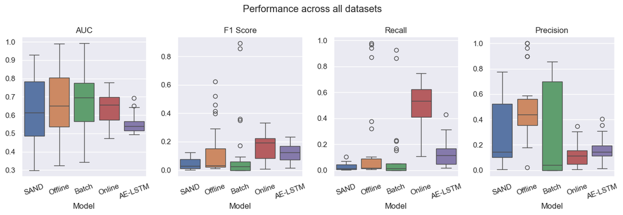

```python
boxplots_comparing_models(results_df, "Performance across all datasets")
```

### 4.3.3. Assessing the impact of different anomaly ratio trends on model performance

```python
sorted_merged_pivot = pd.concat([
    merged_pivot[merged_pivot['rate diff'] < 0].sort_values(by=['rate diff'], ascending=False),
    merged_pivot[merged_pivot['rate diff'] > 0].sort_values(by=['rate diff'])
])
sorted_merged_pivot.reset_index(drop=True)
```

|  | datasets | 0. SAND_AUC | 0. SAND_F | 1. Offline-EncDec-AD_AUC | 1. Offline-EncDec-AD_F | 2. EncDec-AD-Batch_AUC | 2. EncDec-AD-Batch_F | 3. Online-EncDec-AD_AUC | 3. Online-EncDec-AD_F | 4. AE-LSTM_AUC | 4. AE-LSTM_F | si length | si # normal | si positive rate | si # anomalies | si anomaly rate | length | # normal | # anomalies | anomaly rate | rate diff |
| --- | --- | --- | --- | --- | --- | --- | --- | --- | --- | --- | --- | --- | --- | --- | --- | --- | --- | --- | --- | --- | --- |
| 0 | OPPORTUNITY_Genesis_YAHOO | 82.66 | 0.00 | 98.61 | 39.75 | 99.15 | 89.08 | 47.39 | 1.09 | 49.39 | 1.64 | [50000, 16220, 1420] | [48872, 16170, 1418] | [97.74, 99.69, 99.86] | [1128, 50, 2] | [2.26, 0.31, 0.14] | 67640 | 66460 | 1180 | 1.74 | -2.12 |
| 1 | OPPORTUNITY_Genesis_MGAB | 85.11 | 0.00 | 95.63 | 29.34 | 94.08 | 85.45 | 49.18 | 0.86 | 52.11 | 4.28 | [50000, 16220, 50000] | [48872, 16170, 49940] | [97.74, 99.69, 99.88] | [1128, 50, 60] | [2.26, 0.31, 0.12] | 116220 | 114982 | 1238 | 1.07 | -2.14 |
| 2 | ECG_OPPORTUNITY_MGAB | 92.87 | 1.10 | 50.65 | 45.85 | 65.38 | 36.10 | 68.17 | 14.32 | 58.63 | 15.18 | [50000, 50000, 50000] | [47675, 48872, 49940] | [95.35, 97.74, 99.88] | [2325, 1128, 60] | [4.65, 2.26, 0.12] | 150000 | 146487 | 3513 | 2.34 | -4.53 |
| 3 | SensorScope_SMD_ECG | 49.01 | 0.00 | 57.43 | 1.81 | 69.78 | 0.00 | 70.28 | 28.39 | 55.78 | 19.42 | [29553, 28479, 50000] | [25776, 25785, 47675] | [87.22, 90.54, 95.35] | [3777, 2694, 2325] | [12.78, 9.46, 4.65] | 108032 | 99236 | 8796 | 8.14 | -8.13 |
| 4 | SMD_ECG_IOPS | 71.41 | 0.00 | 37.00 | 2.00 | 39.29 | 3.80 | 73.61 | 20.83 | 56.98 | 17.49 | [28479, 50000, 50000] | [25785, 47675, 49776] | [90.54, 95.35, 99.55] | [2694, 2325, 224] | [9.46, 4.65, 0.45] | 128479 | 123236 | 5243 | 4.08 | -9.01 |
| 5 | SMD_ECG_MGAB | 80.06 | 1.45 | 43.94 | 1.28 | 53.36 | 3.95 | 77.89 | 28.64 | 56.61 | 16.84 | [28479, 50000, 50000] | [25785, 47675, 49940] | [90.54, 95.35, 99.88] | [2694, 2325, 60] | [9.46, 4.65, 0.12] | 128479 | 123400 | 5079 | 3.95 | -9.34 |
| 6 | NAB_SMD_IOPS | 42.01 | 0.00 | 71.74 | 1.33 | 57.36 | 0.00 | 64.24 | 11.62 | 51.53 | 6.23 | [2499, 28479, 50000] | [2253, 25785, 49776] | [90.16, 90.54, 99.55] | [246, 2694, 224] | [9.84, 9.46, 0.45] | 80978 | 77814 | 3164 | 3.91 | -9.39 |
| 7 | NAB_Genesis_YAHOO | 62.06 | 0.00 | 54.80 | 14.01 | 63.33 | 17.20 | 66.23 | 8.60 | 69.19 | 13.33 | [2499, 16220, 1420] | [2253, 16170, 1418] | [90.16, 99.69, 99.86] | [246, 50, 2] | [9.84, 0.31, 0.14] | 20139 | 19841 | 298 | 1.48 | -9.70 |
| 8 | NAB_IOPS_YAHOO | 29.95 | 0.00 | 32.37 | 8.93 | 74.72 | 4.38 | 61.22 | 2.62 | 64.95 | 19.94 | [2499, 50000, 1420] | [2253, 49776, 1418] | [90.16, 99.55, 99.86] | [246, 224, 2] | [9.84, 0.45, 0.14] | 53919 | 53447 | 472 | 0.88 | -9.70 |
| 9 | SensorScope_SMD_IOPS | 42.61 | 0.00 | 34.48 | 3.94 | 45.11 | 0.00 | 71.14 | 19.62 | 55.32 | 18.27 | [29553, 28479, 50000] | [25776, 25785, 49776] | [87.22, 90.54, 99.55] | [3777, 2694, 224] | [12.78, 9.46, 0.45] | 108032 | 101337 | 6695 | 6.20 | -12.33 |
| 10 | SensorScope_ECG_GHL | 47.67 | 0.06 | 41.16 | 2.83 | 64.15 | 2.64 | 69.40 | 20.09 | 55.46 | 14.82 | [29553, 50000, 50000] | [25776, 47675, 49856] | [87.22, 95.35, 99.71] | [3777, 2325, 144] | [12.78, 4.65, 0.29] | 129553 | 123307 | 6246 | 4.82 | -12.49 |
| 11 | SensorScope_SMD_GHL | 47.48 | 0.00 | 66.00 | 2.56 | 52.57 | 0.00 | 73.18 | 21.18 | 52.09 | 9.58 | [29553, 28479, 50000] | [25776, 25785, 49856] | [87.22, 90.54, 99.71] | [3777, 2694, 144] | [12.78, 9.46, 0.29] | 108032 | 101417 | 6615 | 6.12 | -12.49 |
| 12 | SensorScope_ECG_MGAB | 51.47 | 0.10 | 42.87 | 2.87 | 71.43 | 2.69 | 71.68 | 27.54 | 56.58 | 18.06 | [29553, 50000, 50000] | [25776, 47675, 49940] | [87.22, 95.35, 99.88] | [3777, 2325, 60] | [12.78, 4.65, 0.12] | 129553 | 123391 | 6162 | 4.76 | -12.66 |
| 13 | SVDB_Occupancy_MITDB | 50.91 | 0.00 | 76.95 | 14.20 | 78.01 | 9.36 | 53.13 | 23.71 | 51.24 | 11.39 | [50000, 8143, 50000] | [23929, 6414, 49641] | [47.86, 78.77, 99.28] | [26071, 1729, 359] | [52.14, 21.23, 0.72] | 108143 | 79984 | 28159 | 26.04 | -51.42 |
| 14 | YAHOO_Genesis_OPPORTUNITY | 78.06 | 0.00 | 98.92 | 62.41 | 89.16 | 0.00 | 57.32 | 6.16 | 50.42 | 2.85 | [1420, 16220, 50000] | [1418, 16170, 48872] | [99.86, 99.69, 97.74] | [2, 50, 1128] | [0.14, 0.31, 2.26] | 67640 | 66460 | 1180 | 1.74 | 2.12 |
| 15 | MGAB_Genesis_OPPORTUNITY | 78.88 | 0.00 | 95.73 | 52.07 | 88.02 | 0.00 | 51.51 | 2.66 | 50.22 | 1.86 | [50000, 16220, 50000] | [49940, 16170, 48872] | [99.88, 99.69, 97.74] | [60, 50, 1128] | [0.12, 0.31, 2.26] | 116220 | 114982 | 1238 | 1.07 | 2.14 |
| 16 | MGAB_OPPORTUNITY_ECG | 79.77 | 11.80 | 70.93 | 41.50 | 69.22 | 35.09 | 66.77 | 16.04 | 53.48 | 7.96 | [50000, 50000, 50000] | [49940, 48872, 47675] | [99.88, 97.74, 95.35] | [60, 1128, 2325] | [0.12, 2.26, 4.65] | 150000 | 146487 | 3513 | 2.34 | 4.53 |
| 17 | ECG_SMD_SensorScope | 62.00 | 3.44 | 74.16 | 2.08 | 76.26 | 0.00 | 65.34 | 26.08 | 54.50 | 16.48 | [50000, 28479, 29553] | [47675, 25785, 25776] | [95.35, 90.54, 87.22] | [2325, 2694, 3777] | [4.65, 9.46, 12.78] | 108032 | 99236 | 8796 | 8.14 | 8.13 |
| 18 | IOPS_ECG_SMD | 67.40 | 12.55 | 59.93 | 1.22 | 54.33 | 5.03 | 67.51 | 16.22 | 50.64 | 3.11 | [50000, 50000, 28479] | [49776, 47675, 25785] | [99.55, 95.35, 90.54] | [224, 2325, 2694] | [0.45, 4.65, 9.46] | 128479 | 123236 | 5243 | 4.08 | 9.01 |
| 19 | MGAB_ECG_SMD | 60.89 | 3.91 | 60.71 | 18.45 | 77.49 | 4.19 | 69.83 | 19.26 | 57.25 | 16.82 | [50000, 50000, 28479] | [49940, 47675, 25785] | [99.88, 95.35, 90.54] | [60, 2325, 2694] | [0.12, 4.65, 9.46] | 128479 | 123400 | 5079 | 3.95 | 9.34 |
| 20 | IOPS_SMD_NAB | 52.84 | 0.00 | 63.95 | 2.39 | 34.38 | 2.86 | 57.32 | 10.68 | 51.87 | 7.35 | [50000, 28479, 2499] | [49776, 25785, 2253] | [99.55, 90.54, 90.16] | [224, 2694, 246] | [0.45, 9.46, 9.84] | 80978 | 77814 | 3164 | 3.91 | 9.39 |
| 21 | YAHOO_Genesis_NAB | 69.41 | 0.00 | 75.04 | 11.30 | 46.56 | 0.00 | 62.43 | 7.52 | 59.86 | 15.12 | [1420, 16220, 2499] | [1418, 16170, 2253] | [99.86, 99.69, 90.16] | [2, 50, 246] | [0.14, 0.31, 9.84] | 20139 | 19841 | 298 | 1.48 | 9.70 |
| 22 | YAHOO_IOPS_NAB | 51.57 | 0.00 | 83.42 | 11.92 | 78.88 | 1.97 | 57.35 | 2.59 | 64.37 | 23.40 | [1420, 50000, 2499] | [1418, 49776, 2253] | [99.86, 99.55, 90.16] | [2, 224, 246] | [0.14, 0.45, 9.84] | 53919 | 53447 | 472 | 0.88 | 9.70 |
| 23 | IOPS_SMD_SensorScope | 47.48 | 0.00 | 56.85 | 2.06 | 66.42 | 0.00 | 65.60 | 20.69 | 51.80 | 7.64 | [50000, 28479, 29553] | [49776, 25785, 25776] | [99.55, 90.54, 87.22] | [224, 2694, 3777] | [0.45, 9.46, 12.78] | 108032 | 101337 | 6695 | 6.20 | 12.33 |
| 24 | GHL_ECG_SensorScope | 85.47 | 11.27 | 80.07 | 2.73 | 68.69 | 0.00 | 65.37 | 22.42 | 52.27 | 9.06 | [50000, 50000, 29553] | [49856, 47675, 25776] | [99.71, 95.35, 87.22] | [144, 2325, 3777] | [0.29, 4.65, 12.78] | 129553 | 123307 | 6246 | 4.82 | 12.49 |
| 25 | GHL_SMD_SensorScope | 51.15 | 0.00 | 55.88 | 2.53 | 74.29 | 0.00 | 63.54 | 20.00 | 51.32 | 7.05 | [50000, 28479, 29553] | [49856, 25785, 25776] | [99.71, 90.54, 87.22] | [144, 2694, 3777] | [0.29, 9.46, 12.78] | 108032 | 101417 | 6615 | 6.12 | 12.49 |
| 26 | MGAB_ECG_SensorScope | 77.61 | 2.85 | 81.79 | 2.83 | 72.44 | 0.00 | 72.82 | 33.25 | 55.54 | 14.74 | [50000, 50000, 29553] | [49940, 47675, 25776] | [99.88, 95.35, 87.22] | [60, 2325, 3777] | [0.12, 4.65, 12.78] | 129553 | 123391 | 6162 | 4.76 | 12.66 |
| 27 | MITDB_Occupancy_SVDB | 40.64 | 1.76 | 86.48 | 11.60 | 85.06 | 9.38 | 52.14 | 22.30 | 50.64 | 10.44 | [50000, 8143, 50000] | [49641, 6414, 23929] | [99.28, 78.77, 47.86] | [359, 1729, 26071] | [0.72, 21.23, 52.14] | 108143 | 79984 | 28159 | 26.04 | 51.42 |

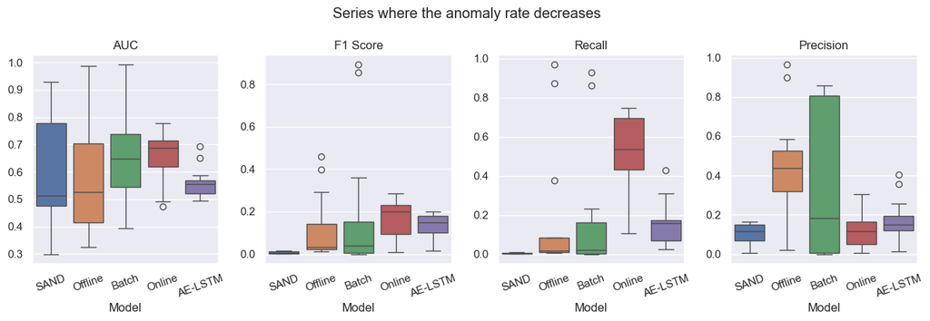

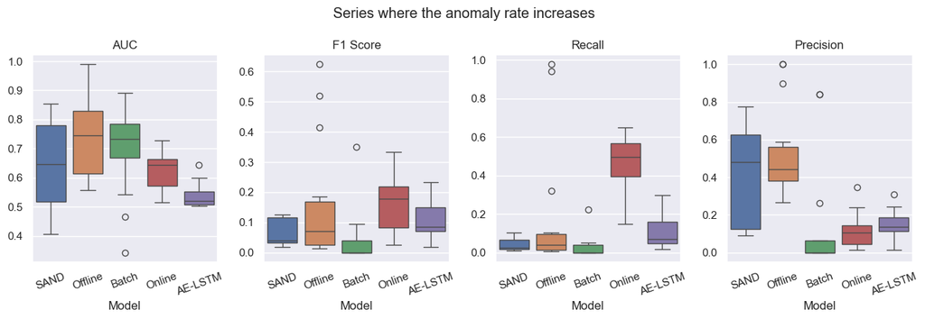

```python
boxplots_comparing_models(merged_results[merged_results['rate diff'] < 0], "Series where the anomaly rate decreases")
boxplots_comparing_models(merged_results[merged_results['rate diff'] > 0], "Series where the anomaly rate increases")
```

### 4.3.4. Dataset characteristics/Model performance correlation

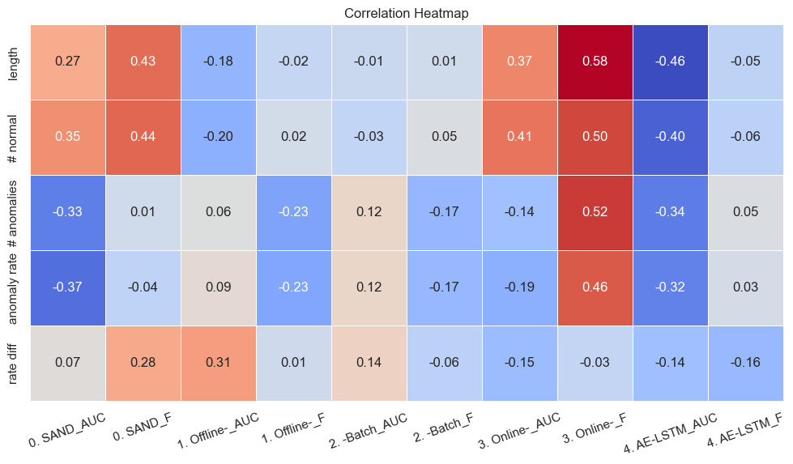

```python
# partial corr matrix
correlations(merged_pivot, n_characteristics)
```

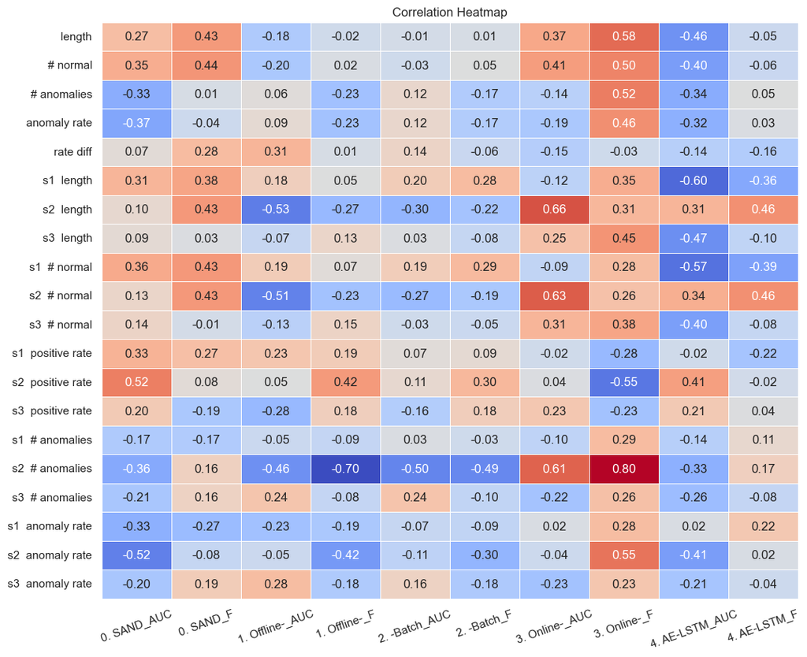

```python
# full corr matrix
merged_pivot_split = split_list_columns(merged_pivot)
n_characteristics = len([col for col in merged_pivot_split.columns if not col[0].isdigit() and col!='datasets'])
correlations(merged_pivot_split, n_characteristics)
```

## 4.4. OnlineEncDec-AD Ablation Study Results

```python
abl_study_res, _ = get_ablation_study_results()
```

### 4.4.1. Ablation study on single normality datasets

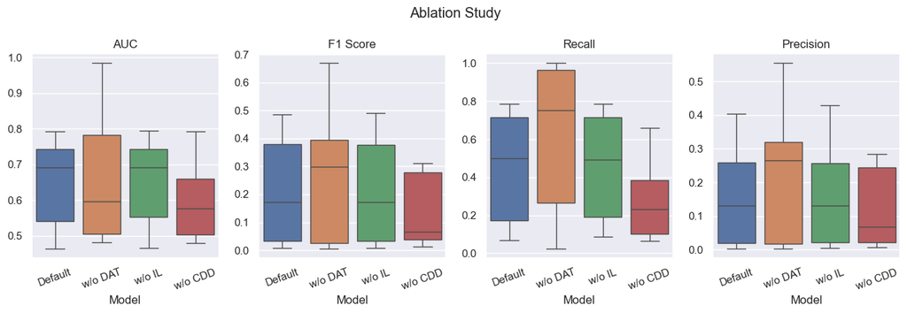

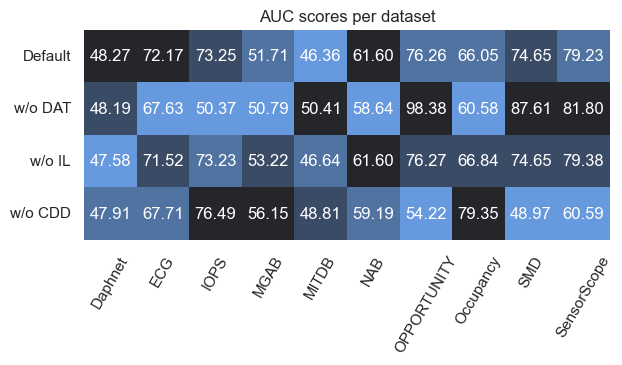

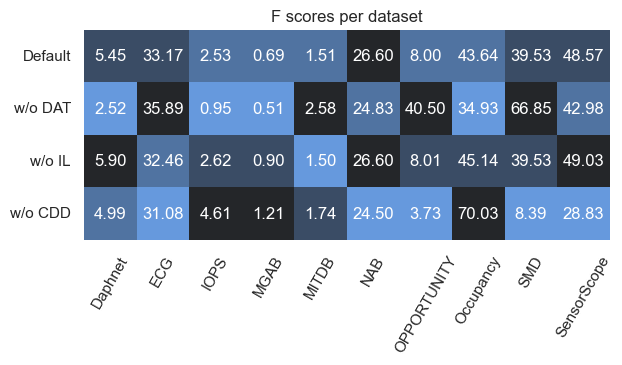

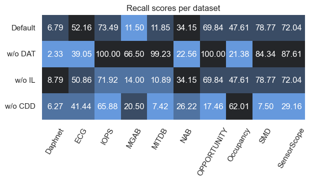

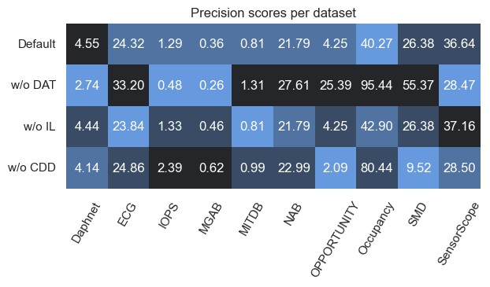

```python
show_ablation_study_results_for_normality(abl_study_res, normality=1)
```

### 4.4.2. Ablation study on double normality datasets

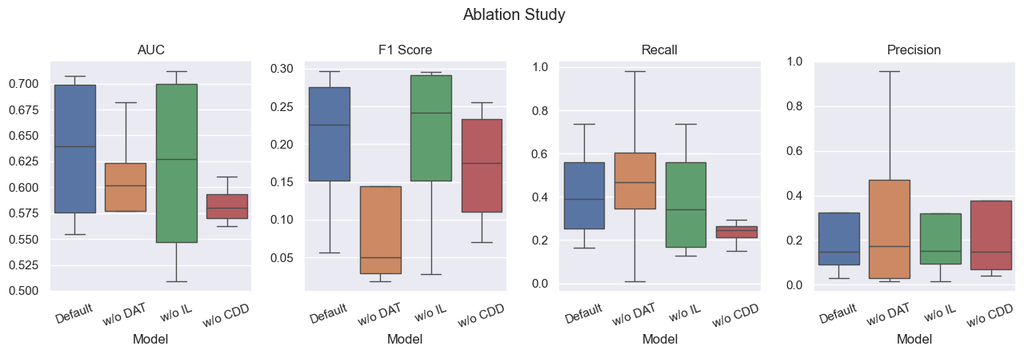

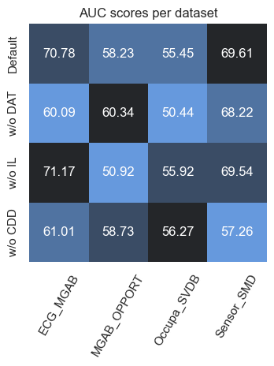

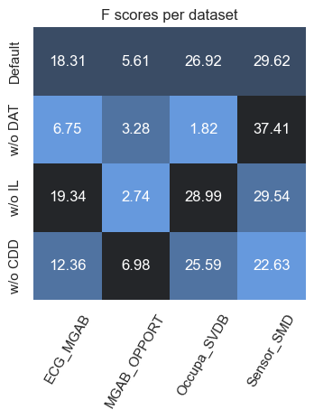

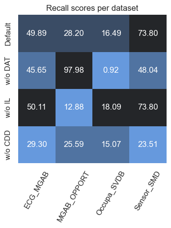

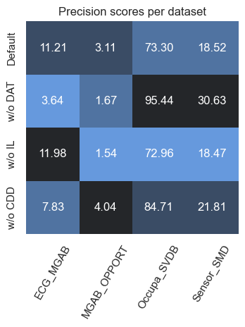

```python
show_ablation_study_results_for_normality(abl_study_res, normality=2)
```

### 4.4.3. Ablation study on triple normality datasets

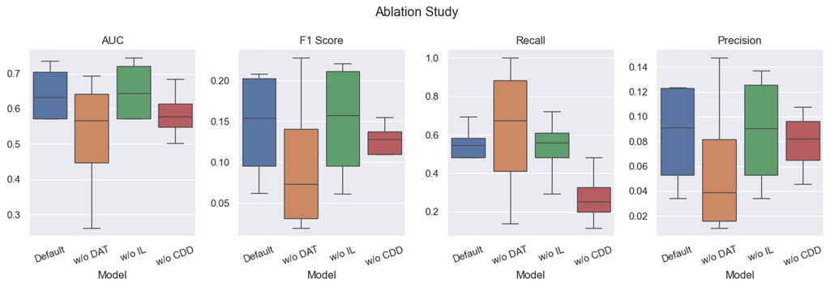

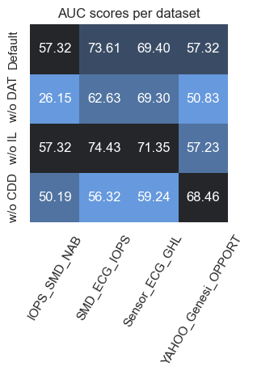

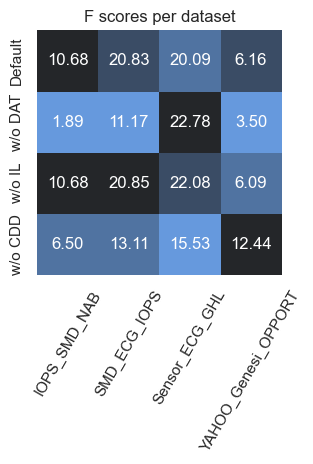

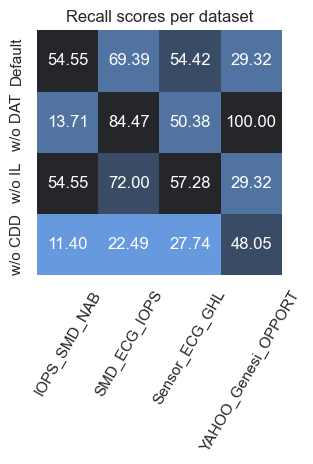

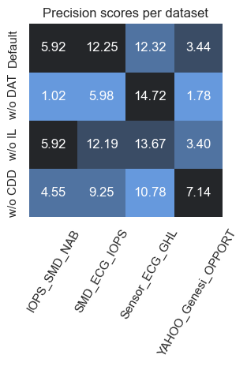

```python
show_ablation_study_results_for_normality(abl_study_res, normality=3)
```